# Predicting Post-COVID Elections Using Pre-COVID Data

Michael Suder, Jeong Hwan Son, Darrell Collison, Bobby Nitto

2025-06-05

## Introduction

Our team used census and demographic data from elections prior to 2020 to develop models that predict the outcome of the 2020 presidential election. Incorporating categorical variables like gender, race/ethnicity and voter education along with continuous variables like median household income, median home value and median age provided us with many key insights we include in our presentation. This document details the steps we took to ingest, transform and model our data. We evaluate our models throughout this document in different ways and summarize our findings at the end.

### Libraries

We use the following libraries in our code below.

sqldf, lubricate, tidyverse, readxl, Amelia, tidymodels, caTools, pROC, brglm2, randomForest, caret, corrr, janitor, patchwork, imputeTS, rLang

### Functions

These functions wrote ourselves and used at different points in the document.

This function finds NA values in a data set and returns the counts by column.

```r
summarizeNAs <- function(df) {
  col_type <- sapply(df,function(col) class(col))
  na_count <- sapply(df, function(col)
    sum(is.na(col)))
  complete_records <- sapply(df,function(col)
    sum(!is.na(col)))
  total_records <- nrow(df)
  percent_complete <- scales::percent(complete_records/total_records)
  dfOut <- data.frame(col_type,na_count=na_count,complete_records,total_records,percent_complete)
  dfOut <- dfOut %>% filter(na_count>1)
  return(dfOut)
}
```

This function creates a csv file from a data frame with a time stamp. Helpful to compare training runs

```r
TstampCSV <- function(df) {
  df_name <- deparse(substitute(df))
  timeStamp <- format(Sys.time(), "%m%d%Y_%H%M%S")
  outFileName <- paste0(df_name,"_",timeStamp,".csv")
  outFile <- write_csv(df,outFileName)
  return(outFile)
}
```

## Data Ingestion & Transformation

This section details the steps taken to ingest and transform our data prior to merging into our analysis data set.

Setting the working directory.

```r
# path = '~/Documents/02 - Education/01 - Syracuse/01 - Spring 2025/01 - Intro to Data Science/12 - Final Project/03 - Code/00 - Data'
path = 'G:/내 드라이브/MasterDegree/2025 Spring/IST687/team_pjt'
list.files(path)
```

```
##  [1] "2009 US Census ACS5 Curated Export.xlsx"
##  [2] "2012-2020 US Census ACS5 Curated Export.xlsx"
##  [3] "code_summary_bobby.pptx"
##  [4] "county_census_and_election_result.csv"
##  [5] "countypres_2000-2020.csv"
##  [6] "Electoral_College.csv"
##  [7] "fp_markdown_060525.html"
##  [8] "fp_markdown_060525.Rmd"
##  [9] "Korean_Predicting-Post-COVID-Elections-Using-Pre-COVID-Data_R1.pptx"
## [10] "meta_data.csv"
## [11] "Predicting-Post-COVID-Elections-Using-Pre-COVID-Data_R1.pptx"
## [12] "spotfire_file.dxp"
## [13] "update1"
## [14] "update2"
## [15] "update3"
```

### MIT County Census Data

Reading in the MIT County Census data

```r
mit_county_data <- read_csv(file.path(path, "countypres_2000-2020.csv"))
```

We start by looking for missing values in the county_fips vector which we will need in our join later on.

```r
mit_county_data_na_cols <- mit_county_data %>%
  filter(is.na(county_fips)) %>%
  distinct(county_name)
mit_county_data_na_cols
```

```
## # A tibble: 3 × 1
##   county_name
##   <chr>
## 1 STATEWIDE WRITEIN
## 2 MAINE UOCAVA
## 3 FEDERAL PRECINCT
```

Using our custom function to provide details on the number of records with missing county_fips data in mit_county_data.

```r
summarizeNAs(mit_county_data)
```

```
##             col_type na_count complete_records total_records percent_complete
## county_fips  numeric       52            72565         72617          99.928%
```

We remove the records with missing county_fips codes as the portion is statistically insignificant. The missing counties also appear to be special cases and should not impact the outcome of our analysis.

```r
mit_county_data <- mit_county_data %>%
  filter(!county_name %in% mit_county_data_na_cols$county_name)
```

There are a few states with missing vote totals so we find the year-state combinations with missing TOTAL rows to identify where we need to make adjustments to the data.

```r
z_state_Total_exisits <- mit_county_data %>%
  select(year, state_po, mode) %>%
  distinct_all() %>%
  mutate(total_exists = if_else(mode == "TOTAL", 1,0)) %>%
  group_by(year, state_po, mode) %>%
  slice_max(order_by = total_exists, n = 1, with_ties = F) %>%
  ungroup() %>%
  # filter(year == 2020) %>%
  group_by(year, state_po) %>%
  summarise(total_exists = sum(total_exists)) %>%
  ungroup() %>%
  filter(total_exists <1) %>%
  select(year, state_po) %>%
  distinct_all()
```

Identifying the year(s) and state(s) with missing totals and storing them as vectors.

```r
## get vector for missing year and state (if any)
missing_total_years <- z_state_Total_exisits$year
missing_total_state <- z_state_Total_exisits$state_po
```

We then filter the MIT County Census data to records missing total vote counts identified previously using the vectors above and aggregate the total vote using the totals from the detailed voting types.

```r
## Create append for the Total values for each year, state, county, party
missing_total_sums_for_append <- mit_county_data %>%
  filter(year %in% missing_total_years
         , state_po %in% missing_total_state
  ) %>%
  group_by(
    year
    ,state
    ,state_po
    ,county_name
    ,county_fips
    ,office
    ,candidate
    ,party
    ,totalvotes
    ,version
  ) %>%
  summarise(candidatevotes = sum(candidatevotes)) %>%
  ungroup() %>%
  mutate(mode = "TOTAL") %>%
  relocate("mode", .after = "version")
```

[output not shown]

This code appends the aggregated missing totals back to the data set and the MIT data is now ready to be merged with the Electoral College data set.

```r
mit_county_data_check <- union_all(mit_county_data, missing_total_sums_for_append) %>%
  filter(mode == "TOTAL")
```

Visualizing the number of voting records we have for each year.

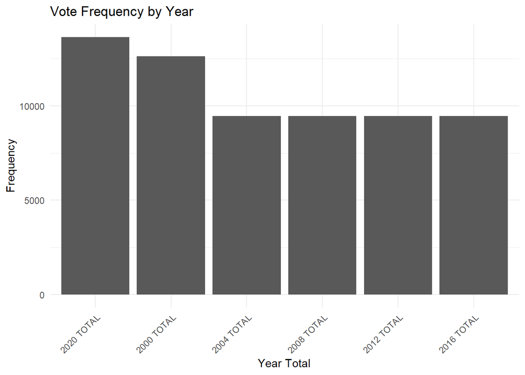

```r
# Filter only TOTAL mode
mit_county_data_check_total <- mit_county_data_check %>%
  filter(mode == "TOTAL")

mit_county_vote_summary_total <- mit_county_data_check_total %>%
  group_by(year) %>%
  count(mode) %>% mutate(yearMode = paste(as.character(year), mode))

mit_county_vote_summary_total %>% ggplot(
  aes(x = fct_reorder(yearMode,-n),y=n)) +
    geom_bar(stat = "identity") + theme_minimal() +
    theme(axis.text.x = element_text(angle = 45, hjust = 1)) +
    ggtitle(paste("Vote Frequency by Year")) +
    xlab("Year Total") +
    ylab("Frequency")
```

### Electoral College Data

Reading in the Electoral College data set from Kaggle.

```r
electoral_college_votes <- read_csv(file.path(path, "electoral_college.csv"))
```

We only want the data for the years 2000 to 2020.

```r
electoral_college_votes <- electoral_college_votes %>% filter(Year >=2000)
```

The columns need to be renamed before we are able to join with the MIT County Census data.

```r
colnames(electoral_college_votes) <- c("year", "state", "ec_votes")
```

### Merging MIT and Electoral College Data

Using left join to bring the two data sets together.

```r
mit_county_ec_data_clean <- mit_county_data_check %>%
  left_join(electoral_college_votes %>% mutate(state = toupper(state)),
            by = c("year", "state")) %>%
  group_by(year, state_po, county_fips) %>%
  mutate(winner = party[which.max(candidatevotes)]) %>%
  ungroup()
```

Taking a look at the structure of the merged MIT County and Electoral College Data

```r
glimpse(mit_county_ec_data_clean)
```

```
## Rows: 64,123
## Columns: 14
## $ year           <dbl> 2000, 2000, 2000, 2000, 2000, 2000, 2000, 2000, 2000, 2…
## $ state          <chr> "ALABAMA", "ALABAMA", "ALABAMA", "ALABAMA", "ALABAMA", …
## $ state_po       <chr> "AL", "AL", "AL", "AL", "AL", "AL", "AL", "AL", "AL", "…
## $ county_name    <chr> "AUTAUGA", "AUTAUGA", "AUTAUGA", "AUTAUGA", "BALDWIN", …
## $ county_fips    <dbl> 1001, 1001, 1001, 1001, 1003, 1003, 1003, 1003, 1005, 1…
## $ office         <chr> "US PRESIDENT", "US PRESIDENT", "US PRESIDENT", "US PRE…
## $ candidate      <chr> "AL GORE", "GEORGE W. BUSH", "RALPH NADER", "OTHER", "A…
## $ party          <chr> "DEMOCRAT", "REPUBLICAN", "GREEN", "OTHER", "DEMOCRAT",…
## $ candidatevotes <dbl> 4942, 11993, 160, 113, 13997, 40872, 1033, 578, 5188, 5…
## $ totalvotes     <dbl> 17208, 17208, 17208, 17208, 56480, 56480, 56480, 56480,…
## $ version        <dbl> 20220315, 20220315, 20220315, 20220315, 20220315, 20220…
## $ mode           <chr> "TOTAL", "TOTAL", "TOTAL", "TOTAL", "TOTAL", "TOTAL", "…
## $ ec_votes       <dbl> 9, 9, 9, 9, 9, 9, 9, 9, 9, 9, 9, 9, 9, 9, 9, 9, 9, 9, 9…
## $ winner         <chr> "REPUBLICAN", "REPUBLICAN", "REPUBLICAN", "REPUBLICAN",…
```

```r
head(mit_county_ec_data_clean)
```

```
## # A tibble: 6 × 14
##    year state   state_po county_name county_fips office       candidate    party
##   <dbl> <chr>   <chr>    <chr>             <dbl> <chr>        <chr>        <chr>
## 1  2000 ALABAMA AL       AUTAUGA            1001 US PRESIDENT AL GORE      DEMO…
## 2  2000 ALABAMA AL       AUTAUGA            1001 US PRESIDENT GEORGE W. B… REPU…
## 3  2000 ALABAMA AL       AUTAUGA            1001 US PRESIDENT RALPH NADER  GREEN
## 4  2000 ALABAMA AL       AUTAUGA            1001 US PRESIDENT OTHER        OTHER
## 5  2000 ALABAMA AL       BALDWIN            1003 US PRESIDENT AL GORE      DEMO…
## 6  2000 ALABAMA AL       BALDWIN            1003 US PRESIDENT GEORGE W. B… REPU…
## # ℹ 6 more variables: candidatevotes <dbl>, totalvotes <dbl>, version <dbl>,
## #   mode <chr>, ec_votes <dbl>, winner <chr>
```

Optionally use the function we created to export the merged data with a data and time stamp.

```r
#TstampCSV(mit_county_ec_data_clean)
```

### County Census API Data

Reading in the County Census API data. This step required two api calls to generate the xlsx files we use in our model.

```r
census_data_2012_2020 <- read_excel(file.path(path, "2012-2020 US Census ACS5 Curated Export.xlsx"))
colnames(census_data_2012_2020)[colnames(census_data_2012_2020) == "Total_Feales"] <- "Total_Females"

census_data_2009 <- read_excel(file.path(path, "2009 US Census ACS5 Curated Export.xlsx"))
colnames(census_data_2009)[colnames(census_data_2009) == "Total_Feales"] <- "Total_Females"
```

Combining the 2 files we have to create a single data set

```r
census_data_bind <- bind_rows(census_data_2012_2020, census_data_2009)
colnames(census_data_bind) <- tolower(colnames(census_data_bind))
```

We found that Employed, Unemployed and Not in Labor Force vectors are missing values. Interpolation is applied to those values to impute the missing data.

```r
census_data_impute <- census_data_bind %>%
  select(-ged_or_alternative) %>%
  group_by(state, fips) %>%
  mutate(
    employed = na_interpolation(employed, option = "linear") ## Impute Employed
    ,unemployed = na_interpolation(unemployed, option = "linear") ## Impute Unemployed
    ,not_in_labor_force = na_interpolation(not_in_labor_force, option = "linear") ## Impute Not in Labor force
  ) %>% ungroup()
```

Here we are applying the 2009 census data to 2008 voting data because that was the earliest data we could find. Our assumption is that voter demographics did not change dramatically between 2008 and 2009.

```r
census_data <- census_data_impute %>%
  mutate(join_year = if_else(year == 2009, 2008, year))
```

### Merging the Final Data Frame

Merging the clean MIT County and Electoral College data with the API Census Data to create our final merged data set.

```r
merged_df <-  mit_county_ec_data_clean %>%
  left_join(census_data %>%
              select(-state, -year) %>%
              ## presidential returns FIPS data does not have leading zeros and is numeric
              mutate(fips = as.numeric(fips)), by = c("county_fips" = "fips", "year"= "join_year")) %>%
  filter(is.na(county_fips) == F) %>%
  na.omit()
```

Creating two subsets of the merged data set with only winners to use in our prediction models.

```r
merged_df_winners_Pre2020 <- merged_df %>%
  filter(year < 2020)%>%
  filter(party == winner) %>%
  select(5,9,10,14,16:46) %>%
  distinct_all()

merged_df_winners_2020 <- merged_df %>%
  filter(year == 2020) %>%
  filter(party == winner) %>%
  select(5,9,10,14,16:46) %>%
  distinct_all()
```

## Summarizing our Merged Data

This section includes the code used to generate the charts for our continuous and categorical variables displayed in our presentation.

Confirming the columns and data types.

```r
glimpse(merged_df)
```

```
## Rows: 41,447
## Columns: 46
## $ year                             <dbl> 2008, 2008, 2008, 2008, 2008, 2008, 2…
## $ state                            <chr> "ALABAMA", "ALABAMA", "ALABAMA", "ALA…
## $ state_po                         <chr> "AL", "AL", "AL", "AL", "AL", "AL", "…
## $ county_name                      <chr> "AUTAUGA", "AUTAUGA", "AUTAUGA", "BAL…
## $ county_fips                      <dbl> 1001, 1001, 1001, 1003, 1003, 1003, 1…
## $ office                           <chr> "US PRESIDENT", "US PRESIDENT", "US P…
## $ candidate                        <chr> "BARACK OBAMA", "JOHN MCCAIN", "OTHER…
## $ party                            <chr> "DEMOCRAT", "REPUBLICAN", "OTHER", "D…
## $ candidatevotes                   <dbl> 6093, 17403, 145, 19386, 61271, 756, …
## $ totalvotes                       <dbl> 23641, 23641, 23641, 81413, 81413, 81…
## $ version                          <dbl> 20220315, 20220315, 20220315, 2022031…
## $ mode                             <chr> "TOTAL", "TOTAL", "TOTAL", "TOTAL", "…
## $ ec_votes                         <dbl> 9, 9, 9, 9, 9, 9, 9, 9, 9, 9, 9, 9, 9…
```

[output cut: 33 more lines]

Verifying there are no missing records using the Amelia library and the missmap function. The function we wrote to check for NAs also returns no missing records.

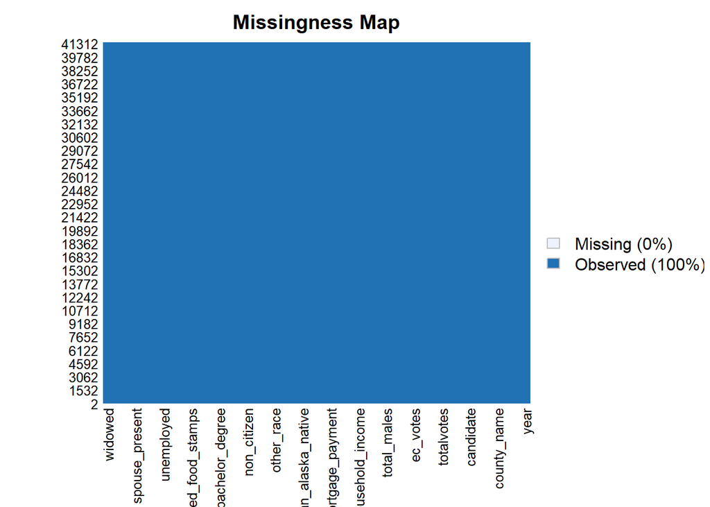

```r
missmap(merged_df)
```

```r
summarizeNAs(merged_df)
```

```
## [1] col_type         na_count         complete_records total_records
## [5] percent_complete
## <0 rows> (or 0-length row.names)
```

### Visualizing Continuous Variables

#### Facet Bar Chart

```r
median_vars_df <- merged_df %>% select(
  year,
  median_household_income,
  median_home_value,
  median_mortgage_payment
) %>% group_by(year) %>% summarise(
    med_median_household_income = median(median_household_income, na.rm =TRUE),
    med_median_home_value = median(median_home_value, na.rm = TRUE),
    med_median_mortgage_payment = median(median_mortgage_payment, na.rm = TRUE))
head(median_vars_df)
```

```
## # A tibble: 4 × 4
##    year med_median_household_income med_median_home_value med_median_mortgage_…¹
##   <dbl>                       <dbl>                 <dbl>                  <dbl>
## 1  2008                      41595                 102100                    656
## 2  2012                      43768                 107600                    688
## 3  2016                      46258.                114400                    676
## 4  2020                      53063                 135000                    723
## # ℹ abbreviated name: ¹med_median_mortgage_payment
```

```r
median_vars_df_pivot <- median_vars_df %>% pivot_longer(cols = c(med_median_home_value,med_median_household_income,med_median_mortgage_payment), names_to = "variable", values_to = "value") %>% mutate(
    variable = recode(
      variable,
      med_median_home_value = "Home Value",
      med_median_household_income = "Household Income",
      med_median_mortgage_payment = "Mortgage Payment"
    ),
    variable = factor(variable, levels = c(
      "Home Value",
      "Household Income",
      "Mortgage Payment"
    ))
  )
median_vars_df_pivot$year <- as.factor(median_vars_df_pivot$year)
head(median_vars_df_pivot,20)
```

```
## # A tibble: 12 × 3
##    year  variable           value
##    <fct> <fct>              <dbl>
##  1 2008  Home Value       102100
##  2 2008  Household Income  41595
##  3 2008  Mortgage Payment    656
##  4 2012  Home Value       107600
##  5 2012  Household Income  43768
##  6 2012  Mortgage Payment    688
##  7 2016  Home Value       114400
##  8 2016  Household Income  46258.
##  9 2016  Mortgage Payment    676
## 10 2020  Home Value       135000
## 11 2020  Household Income  53063
## 12 2020  Mortgage Payment    723
```

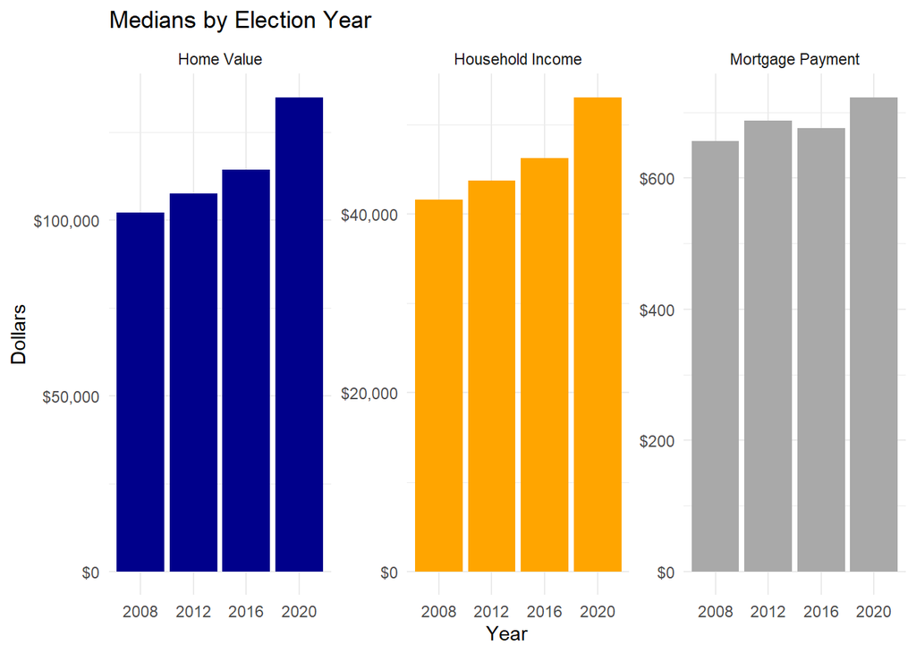

```r
fill_colors <- c(
  "Home Value" = "darkblue",
  "Household Income" = "orange",
  "Mortgage Payment" = "darkgrey"
)
ggplot(median_vars_df_pivot, aes(x = year, y = value, fill = variable)) +
  geom_bar(stat = "identity", position = "dodge") +
  scale_fill_manual(values=fill_colors) +
  scale_y_continuous(labels = dollar_format()) +
  facet_wrap(~ variable, scales = "free_y") +
  labs(title = "Medians by Election Year",
       x = "Year",
       y = "Dollars") +
  theme_minimal() + theme(legend.position = "none")
```

#### Box Plots

##### Median Home Value

```r
median_home_value_df_box <- merged_df %>% select(
  year,
  median_home_value,
) %>% group_by(year)

mhv_quartiles_df <- median_home_value_df_box %>%
  group_by(year) %>%
  summarise(
    Q1 = quantile(median_home_value, 0.25, na.rm = TRUE),
    Median = quantile(median_home_value, 0.5, na.rm = TRUE),
    Q3 = quantile(median_home_value, 0.75, na.rm = TRUE)
  )

median_home_value_df_box
```

```
## # A tibble: 41,447 × 2
## # Groups:   year [4]
##     year median_home_value
##    <dbl>             <dbl>
##  1  2008            130700
##  2  2008            130700
##  3  2008            130700
##  4  2008            173100
##  5  2008            173100
##  6  2008            173100
##  7  2008             83400
##  8  2008             83400
##  9  2008             83400
## 10  2008             81300
## # ℹ 41,437 more rows
```

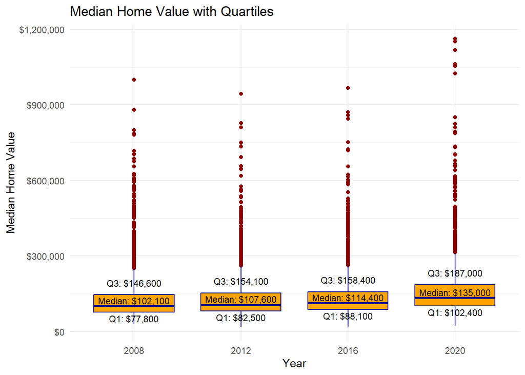

```r
ggplot(median_home_value_df_box, aes(x = factor(year), y = median_home_value)) +
  geom_boxplot(fill = "orange", color = "darkblue", outlier.color = "darkred") +
  geom_text(data = mhv_quartiles_df, aes(x = factor(year), y = Q1, label = paste0("Q1: ", dollar(Q1))),
            vjust = 1.4, size = 3, color = "black") +
  geom_text(data = mhv_quartiles_df, aes(x = factor(year), y = Median, label = paste0("Median: ", dollar(Median))),
            vjust = -.3, size = 3, color = "black") +
  geom_text(data = mhv_quartiles_df, aes(x = factor(year), y = Q3, label = paste0("Q3: ", dollar(Q3))),
            vjust = -1.2, size = 3, color = "black") +
  scale_y_continuous(labels = label_dollar()) +
  labs(
    title = "Median Home Value with Quartiles",
    x = "Year",
    y = "Median Home Value"
  ) + theme_minimal()
```

##### Median Household Income

```r
# create the data set
median_household_income_df_box <- merged_df %>% select(
  year,
  median_household_income,
) %>% group_by(year)

mhi_quartiles_df <- median_household_income_df_box %>%
  group_by(year) %>%
  summarise(
    Q1 = quantile(median_household_income, 0.25, na.rm = TRUE),
    Median = quantile(median_household_income, 0.5, na.rm = TRUE),
    Q3 = quantile(median_household_income, 0.75, na.rm = TRUE)
  )

median_household_income_df_box
```

```
## # A tibble: 41,447 × 2
## # Groups:   year [4]
##     year median_household_income
##    <dbl>                   <dbl>
##  1  2008                   51463
##  2  2008                   51463
##  3  2008                   51463
##  4  2008                   48918
##  5  2008                   48918
##  6  2008                   48918
##  7  2008                   32537
##  8  2008                   32537
##  9  2008                   32537
## 10  2008                   41236
## # ℹ 41,437 more rows
```

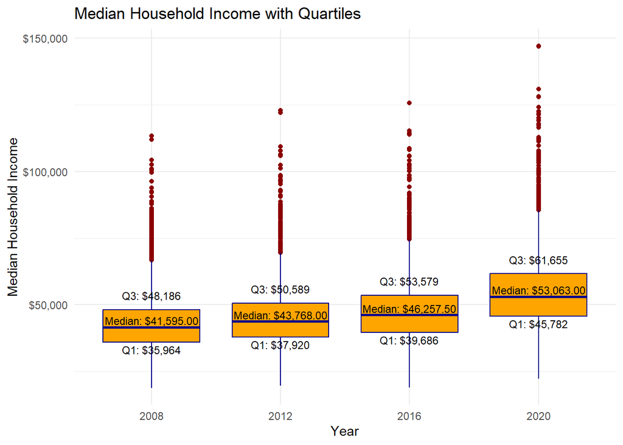

```r
ggplot(median_household_income_df_box, aes(x = factor(year), y = median_household_income)) +
  geom_boxplot(fill = "orange", color = "darkblue", outlier.color = "darkred") +
  geom_text(data = mhi_quartiles_df, aes(x = factor(year), y = Q1, label = paste0("Q1: ", dollar(Q1))),
            vjust = 1.4, size = 3, color = "black") +
  geom_text(data = mhi_quartiles_df, aes(x = factor(year), y = Median, label = paste0("Median: ", dollar(Median))),
            vjust = -.3, size = 3, color = "black") +
  geom_text(data = mhi_quartiles_df, aes(x = factor(year), y = Q3, label = paste0("Q3: ", dollar(Q3))),
            vjust = -1.2, size = 3, color = "black") +
  scale_y_continuous(labels = label_dollar()) +
  labs(
    title = "Median Household Income with Quartiles",
    x = "Year",
    y = "Median Household Income"
  ) + theme_minimal()
```

##### Median Mortgage Payment

```r
median_mortgage_payment_df_box <- merged_df %>% select(
  year,
  median_mortgage_payment,
) %>% group_by(year)

mmp_quartiles_df <- median_mortgage_payment_df_box %>%
  group_by(year) %>%
  summarise(
    Q1 = quantile(median_mortgage_payment, 0.25, na.rm = TRUE),
    Median = quantile(median_mortgage_payment, 0.5, na.rm = TRUE),
    Q3 = quantile(median_mortgage_payment, 0.75, na.rm = TRUE)
  )

median_mortgage_payment_df_box
```

```
## # A tibble: 41,447 × 2
## # Groups:   year [4]
##     year median_mortgage_payment
##    <dbl>                   <dbl>
##  1  2008                     854
##  2  2008                     854
##  3  2008                     854
##  4  2008                     846
##  5  2008                     846
##  6  2008                     846
##  7  2008                     535
##  8  2008                     535
##  9  2008                     535
## 10  2008                     466
## # ℹ 41,437 more rows
```

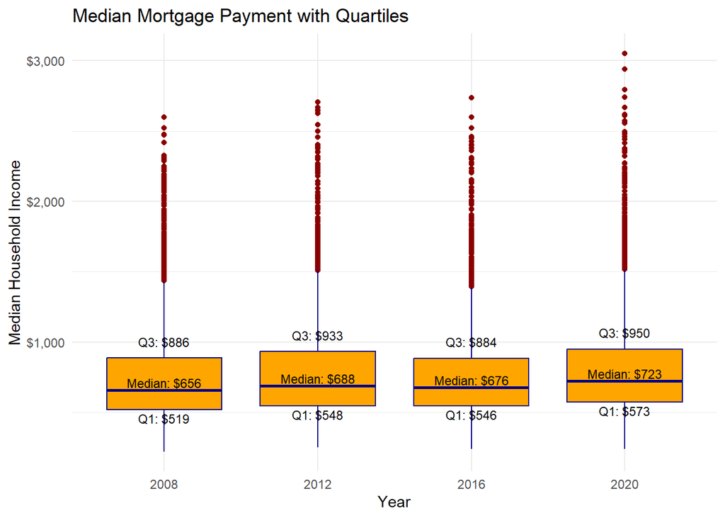

```r
ggplot(median_mortgage_payment_df_box, aes(x = factor(year), y = median_mortgage_payment)) +
  geom_boxplot(fill = "orange", color = "darkblue", outlier.color = "darkred") +
  geom_text(data = mmp_quartiles_df, aes(x = factor(year), y = Q1, label = paste0("Q1: ", dollar(Q1))),
            vjust = 1.4, size = 3, color = "black") +
  geom_text(data = mmp_quartiles_df, aes(x = factor(year), y = Median, label = paste0("Median: ", dollar(Median))),
            vjust = -.3, size = 3, color = "black") +
  geom_text(data = mmp_quartiles_df, aes(x = factor(year), y = Q3, label = paste0("Q3: ", dollar(Q3))),
            vjust = -1.2, size = 3, color = "black") +
  scale_y_continuous(labels = label_dollar()) +
  labs(
    title = "Median Mortgage Payment with Quartiles",
    x = "Year",
    y = "Median Household Income"
  ) + theme_minimal()
```

##### Median Age

```r
# create the data set
median_age_df_box <- merged_df %>% select(
  year,
  median_age,
) %>% group_by(year)

mage_quartiles_df <- median_age_df_box %>%
  group_by(year) %>%
  summarise(
    Q1 = quantile(median_age, 0.25, na.rm = TRUE),
    Median = quantile(median_age, 0.5, na.rm = TRUE),
    Q3 = quantile(median_age, 0.75, na.rm = TRUE)
  )

median_age_df_box
```

```
## # A tibble: 41,447 × 2
## # Groups:   year [4]
##     year median_age
##    <dbl>      <dbl>
##  1  2008       36
##  2  2008       36
##  3  2008       36
##  4  2008       41
##  5  2008       41
##  6  2008       41
##  7  2008       37.5
##  8  2008       37.5
##  9  2008       37.5
## 10  2008       38.6
## # ℹ 41,437 more rows
```

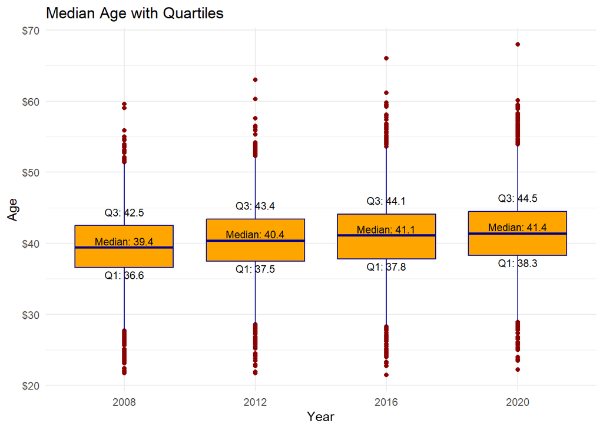

```r
ggplot(median_age_df_box, aes(x = factor(year), y = median_age)) +
  geom_boxplot(fill = "orange", color = "darkblue", outlier.color = "darkred") +
  geom_text(data = mage_quartiles_df, aes(x = factor(year), y = Q1, label = paste0("Q1: ", Q1)),
            vjust = 1.4, size = 3, color = "black") +
  geom_text(data = mage_quartiles_df, aes(x = factor(year), y = Median, label = paste0("Median: ", Median)),
            vjust = -.3, size = 3, color = "black") +
  geom_text(data = mage_quartiles_df, aes(x = factor(year), y = Q3, label = paste0("Q3: ", Q3)),
            vjust = -1.2, size = 3, color = "black") +
  scale_y_continuous(labels = label_dollar()) +
  labs(
    title = "Median Age with Quartiles",
    x = "Year",
    y = "Age"
  ) + theme_minimal()
```

### Visualizing Categorical Variables

#### Race/Ethnicity by Election Year

```r
race_ethnicity_df <- merged_df %>% select(
  year,
  white,
  black,
  native_hawaiian_pacific_islander,
  american_indian_alaska_native,
  asian_alone,
  other_race,
  hispanic_or_latino
) %>% group_by(year) %>%
  summarise(
    total_white = sum(white, na.rm = TRUE),
    total_black = sum(black, na.rm = TRUE),
    total_nhpi = sum(native_hawaiian_pacific_islander),
    total_aian = sum(american_indian_alaska_native),
    total_asian_alone = sum(asian_alone),
    total_other_race = sum(other_race),
    total_his_or_lat = sum(hispanic_or_latino)
  ) %>% mutate(total_population=total_white+total_black+total_nhpi+total_aian+total_asian_alone+total_other_race+total_his_or_lat)
```

```r
re_df_pivot <- race_ethnicity_df %>% select(-total_population) %>% pivot_longer(cols = c(total_white,total_black,total_nhpi,total_aian,total_asian_alone,total_other_race,total_his_or_lat), names_to = "variable", values_to = "value") %>% mutate(variable = recode(variable,
                           total_white = "White",
                           total_black = "Black or African American",
                           total_nhpi = "Native Hawaiian Pacific Islander",
                           total_aian = "American Indian Alaska Native",
                           total_asian_alone = "Asian",
                           total_his_or_lat = "Hispanic or Latino",
                           total_other_race = "Other"))
re_df_pivot <- re_df_pivot %>% group_by(year) %>% mutate(percentage=value/sum(value))
re_df_pivot$year <- as.factor(re_df_pivot$year)
head(re_df_pivot,20)
```

```
## # A tibble: 20 × 4
## # Groups:   year [3]
##    year  variable                             value percentage
##    <fct> <chr>                                <dbl>      <dbl>
##  1 2008  White                            671967606    0.660
##  2 2008  Black or African American        110796843    0.109
##  3 2008  Native Hawaiian Pacific Islander   1338780    0.00132
##  4 2008  American Indian Alaska Native      7039530    0.00692
##  5 2008  Asian                             39517866    0.0388
##  6 2008  Other                             50874489    0.0500
##  7 2008  Hispanic or Latino               136234056    0.134
##  8 2012  White                            686336223    0.653
##  9 2012  Black or African American        115529637    0.110
## 10 2012  Native Hawaiian Pacific Islander   1538016    0.00146
## 11 2012  American Indian Alaska Native      7346142    0.00699
## 12 2012  Asian                             44479533    0.0423
## 13 2012  Other                             44371965    0.0422
## 14 2012  Hispanic or Latino               151416921    0.144
## 15 2016  White                            699304824    0.642
## 16 2016  Black or African American        119748783    0.110
## 17 2016  Native Hawaiian Pacific Islander   1673508    0.00154
## 18 2016  American Indian Alaska Native      7544679    0.00693
## 19 2016  Asian                             49728492    0.0457
## 20 2016  Other                             45302871    0.0416
```

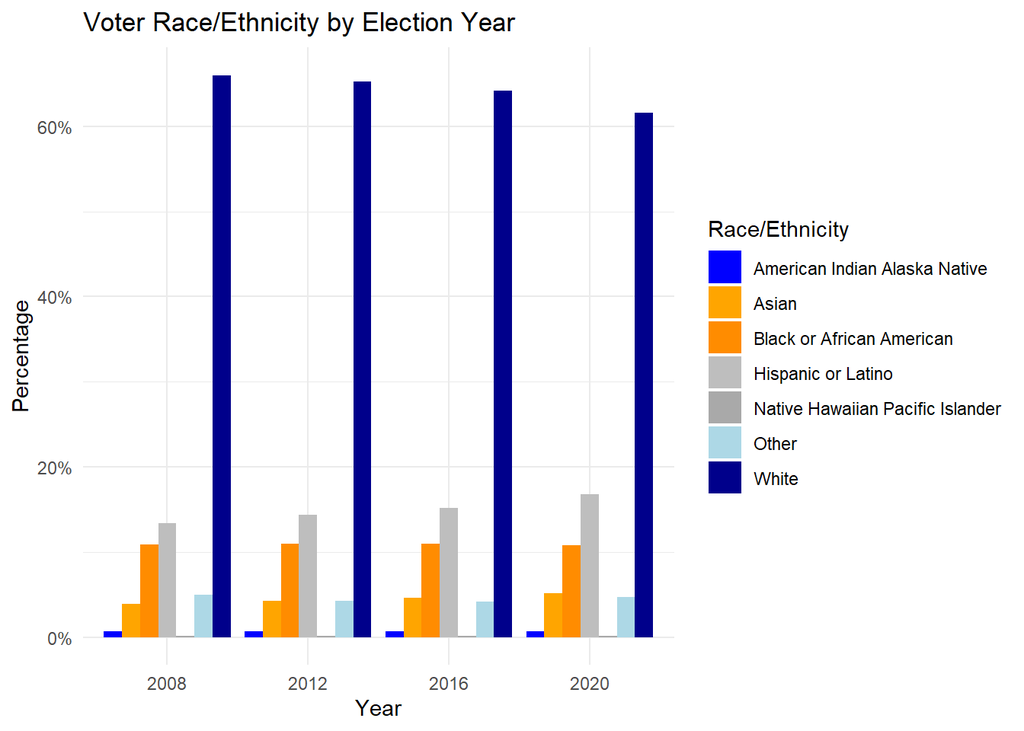

```r
re_fill_colors <- c(
  "White" = "darkblue",
  "Black or African American" = "darkorange",
  "Native Hawaiian Pacific Islander" = "darkgrey",
  "American Indian Alaska Native" = "blue",
  "Asian" = "orange",
  "Hispanic or Latino" = "gray",
  "Other" = "lightblue"
)
ggplot(re_df_pivot, aes(x = year, y = percentage, fill = variable)) +
  geom_bar(stat = "identity", position = "dodge") +
  scale_y_continuous(labels = percent_format()) +
  scale_fill_manual(name = "Race/Ethnicity",values = re_fill_colors) +
  labs(title = "Voter Race/Ethnicity by Election Year",
       x = "Year",
       y = "Percentage") +
  theme_minimal()
```

#### Citizenship by Election Year

```r
citizenship_df <- merged_df %>% select(
  year,
  citizen,
  non_citizen
) %>% group_by(year) %>%
  summarise(
    total_citizen = sum(citizen, na.rm = TRUE),
    total_non_citizen = sum(non_citizen, na.rm = TRUE),
  ) %>% mutate(total=total_citizen + total_non_citizen)
head(citizenship_df)
```

```
## # A tibble: 4 × 4
##    year total_citizen total_non_citizen      total
##   <dbl>         <dbl>             <dbl>      <dbl>
## 1  2008     778076076          64109157  842185233
## 2  2012     792589047          66257097  858846144
## 3  2016     812053587          66453864  878507451
## 4  2020    1257233291         102827177 1360060468
```

```r
citizenship_df_pivot <- citizenship_df %>% pivot_longer(cols = c(total_citizen,total_non_citizen), names_to = "variable", values_to = "value") %>% mutate(variable = recode(variable,
                           total_citizen = "Citizen",
                           total_non_citizen = "Non-Citizen"))
citizenship_df_pivot <- citizenship_df_pivot %>% group_by(year) %>% mutate(percentage=value/sum(value))
citizenship_df_pivot$year <- as.factor(citizenship_df_pivot$year)
head(citizenship_df_pivot,20)
```

```
## # A tibble: 8 × 5
## # Groups:   year [4]
##   year       total variable         value percentage
##   <fct>      <dbl> <chr>            <dbl>      <dbl>
## 1 2008   842185233 Citizen      778076076     0.924
## 2 2008   842185233 Non-Citizen   64109157     0.0761
## 3 2012   858846144 Citizen      792589047     0.923
## 4 2012   858846144 Non-Citizen   66257097     0.0771
## 5 2016   878507451 Citizen      812053587     0.924
## 6 2016   878507451 Non-Citizen   66453864     0.0756
## 7 2020  1360060468 Citizen     1257233291     0.924
## 8 2020  1360060468 Non-Citizen  102827177     0.0756
```

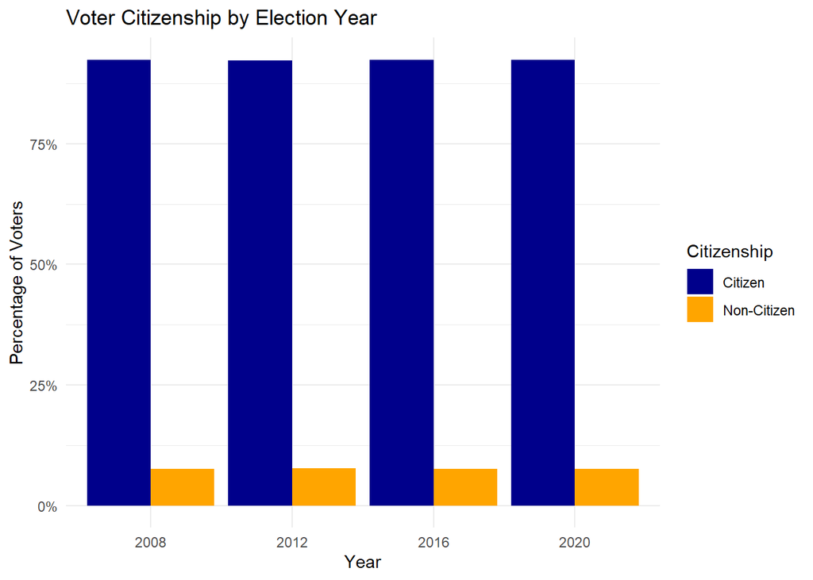

```r
c_fill_colors <- c("Citizen" = "darkblue", "Non-Citizen"="orange")
ggplot(citizenship_df_pivot, aes(x = year, y = percentage, fill = variable)) +
  geom_bar(stat = "identity", position = "dodge") +
  scale_y_continuous(labels = percent_format()) +
  scale_fill_manual(name = "Citizenship", values = c_fill_colors) +
  labs(title = "Voter Citizenship by Election Year",
       x = "Year",
       y = "Percentage of Voters") +
  theme_minimal()
```

#### Education Level by Year

```r
education_df <- merged_df %>% select(
  year,
  high_school_education,
  associates_degree,
  bachelor_degree,
  masters_degree,
  doctoral_degree
) %>% group_by(year) %>%
  summarise(
    total_high_school = sum(high_school_education, na.rm = TRUE),
    total_associates = sum(associates_degree, na.rm = TRUE),
    total_bachelor = sum(bachelor_degree,na.rm=TRUE),
    total_masters = sum(masters_degree,na.rm=TRUE),
    total_doctoral = sum(doctoral_degree,na.rm=TRUE)
  ) %>% mutate(total=total_high_school+total_associates+total_bachelor+total_masters+total_doctoral)
head(education_df)
```

```
## # A tibble: 4 × 7
##    year total_high_school total_associates total_bachelor total_masters
##   <dbl>             <dbl>            <dbl>          <dbl>         <dbl>
## 1  2008         173104983         43894986      102797829      41471727
## 2  2012         148657668         47111436      109187430      45313032
## 3  2016         150457515         52298379      120111981      52024371
## 4  2020         228902750         88244060      206744625      92633659
## # ℹ 2 more variables: total_doctoral <dbl>, total <dbl>
```

```r
education_df_pivot <- education_df %>% pivot_longer(cols = c(total_high_school,total_associates,total_bachelor,total_masters,total_doctoral), names_to = "variable", values_to = "value") %>% mutate(variable = recode(variable,
                           total_high_school = "High School Diploma",
                           total_associates = "Associates Degree",
                           total_bachelor = "Bachelors Degree",
                           total_masters = "Masters Degree",
                           total_doctoral = "Doctorate Degree"))
education_df_pivot <- education_df_pivot %>% group_by(year) %>% mutate(percentage=value/sum(value))
education_df_pivot$year <- as.factor(education_df_pivot$year)
head(education_df_pivot,20)
```

```
## # A tibble: 20 × 5
## # Groups:   year [4]
##    year      total variable                value percentage
##    <fct>     <dbl> <chr>                   <dbl>      <dbl>
##  1 2008  367904514 High School Diploma 173104983     0.471
##  2 2008  367904514 Associates Degree    43894986     0.119
##  3 2008  367904514 Bachelors Degree    102797829     0.279
##  4 2008  367904514 Masters Degree       41471727     0.113
##  5 2008  367904514 Doctorate Degree      6634989     0.0180
##  6 2012  357670221 High School Diploma 148657668     0.416
##  7 2012  357670221 Associates Degree    47111436     0.132
##  8 2012  357670221 Bachelors Degree    109187430     0.305
##  9 2012  357670221 Masters Degree       45313032     0.127
## 10 2012  357670221 Doctorate Degree      7400655     0.0207
## 11 2016  383415018 High School Diploma 150457515     0.392
## 12 2016  383415018 Associates Degree    52298379     0.136
## 13 2016  383415018 Bachelors Degree    120111981     0.313
## 14 2016  383415018 Masters Degree       52024371     0.136
## 15 2016  383415018 Doctorate Degree      8522772     0.0222
## 16 2020  631388885 High School Diploma 228902750     0.363
## 17 2020  631388885 Associates Degree    88244060     0.140
## 18 2020  631388885 Bachelors Degree    206744625     0.327
## 19 2020  631388885 Masters Degree       92633659     0.147
## 20 2020  631388885 Doctorate Degree     14863791     0.0235
```

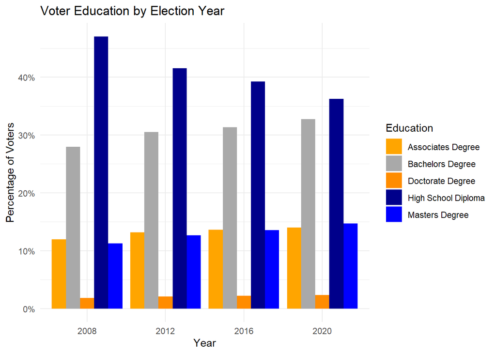

```r
e_fill_colors <- c("High School Diploma" = "darkblue", "Associates Degree"="orange","Bachelors Degree"="darkgrey","Masters Degree"="blue","Doctorate Degree" = "darkorange")
ggplot(education_df_pivot, aes(x = year, y = percentage, fill = variable)) +
  geom_bar(stat = "identity", position = "dodge") +
  scale_y_continuous(labels = percent_format()) +
  scale_fill_manual(name = "Education", values = e_fill_colors) +
  labs(title = "Voter Education by Election Year",
       x = "Year",
       y = "Percentage of Voters") +
  theme_minimal()
```

#### Employment by Election Year

```r
employment_df <- merged_df %>% select(
  year,
  employed,
  unemployed,
  not_in_labor_force
) %>% group_by(year) %>%
  summarise(
    total_employed = sum(employed, na.rm = TRUE),
    total_unemployed = sum(unemployed, na.rm = TRUE),
    total_not_in_labor_force = sum(not_in_labor_force, na.rm= TRUE)) %>%
  mutate(total=total_employed + total_unemployed)
head(employment_df)
```

```
## # A tibble: 4 × 5
##    year total_employed total_unemployed total_not_in_labor_force     total
##   <dbl>          <dbl>            <dbl>                    <dbl>     <dbl>
## 1  2008      465956841         26471157                286376544 492427998
## 2  2012      424501770         43442508                257648016 467944278
## 3  2016      442375797         35256828                276686628 477632625
## 4  2020      712272003         40638302                437443804 752910305
```

```r
employment_df_pivot <- employment_df %>% select(-total) %>% pivot_longer(
  cols = c(total_employed, total_unemployed, total_not_in_labor_force),
  names_to = "variable",
  values_to = "value"
) %>% mutate(variable = recode(
  variable,
  total_employed = "Employed",
  total_unemployed = "Unemployed",
  total_not_in_labor_force = "Not in Labor Force"
))

employment_df_pivot <- employment_df_pivot %>% group_by(year) %>% mutate(percentage =
                                                                         value / sum(value))
employment_df_pivot$year <- as.factor(employment_df_pivot$year)
head(employment_df_pivot,20)
```

```
## # A tibble: 12 × 4
## # Groups:   year [4]
##    year  variable               value percentage
##    <fct> <chr>                  <dbl>      <dbl>
##  1 2008  Employed           465956841     0.598
##  2 2008  Unemployed          26471157     0.0340
##  3 2008  Not in Labor Force 286376544     0.368
##  4 2012  Employed           424501770     0.585
##  5 2012  Unemployed          43442508     0.0599
##  6 2012  Not in Labor Force 257648016     0.355
##  7 2016  Employed           442375797     0.586
##  8 2016  Unemployed          35256828     0.0467
##  9 2016  Not in Labor Force 276686628     0.367
## 10 2020  Employed           712272003     0.598
## 11 2020  Unemployed          40638302     0.0341
## 12 2020  Not in Labor Force 437443804     0.367
```

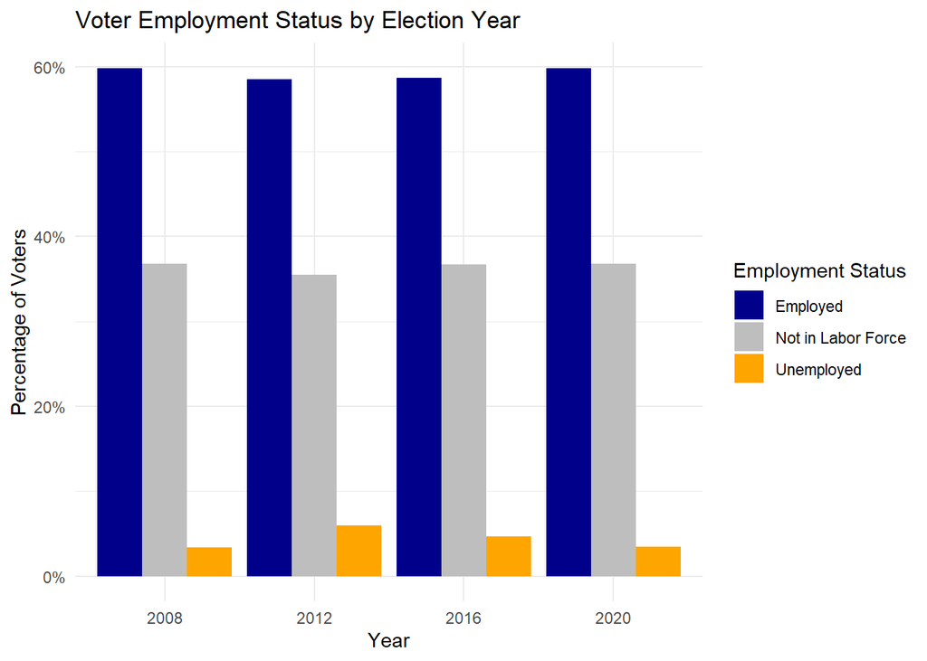

```r
emp_fill_colors <- c("Employed"="darkblue","Unemployed"="orange","Not in Labor Force"="gray")
ggplot(employment_df_pivot, aes(x = year, y = percentage, fill = variable)) +
  geom_bar(stat = "identity", position = "dodge") +
  scale_y_continuous(labels = percent_format()) +
  scale_fill_manual(name = "Employment Status",values = emp_fill_colors) +
  labs(title = "Voter Employment Status by Election Year",
       x = "Year",
       y = "Percentage of Voters") +
  theme_minimal()
```

#### Marital Status by Election Year

```r
marital_status_df <- merged_df %>% select(
  year,
  never_married,
  spouse_present,
  spouse_absent,
  spouse_seperated,
  widowed
) %>% group_by(year) %>%
  summarise(
    total_never_married = sum(never_married, na.rm = TRUE),
    total_spouse_present = sum(spouse_present, na.rm = TRUE),
    total_spouse_absent = sum(spouse_absent, na.rm= TRUE),
    total_spouse_seperated = sum(spouse_seperated, na.rm=TRUE),
    total_widowed = sum(widowed,na.rm=TRUE)) %>%
  mutate(total=total_never_married + total_spouse_present + total_spouse_absent + total_spouse_seperated + total_widowed)
head(marital_status_df)
```

```
## # A tibble: 4 × 7
##    year total_never_married total_spouse_present total_spouse_absent
##   <dbl>               <dbl>                <dbl>               <dbl>
## 1  2008           220948185            342443553            34712298
## 2  2012           235672755            346482960            35038176
## 3  2016           253842342            349615548            36793479
## 4  2020           407582673            551405779            55271852
## # ℹ 3 more variables: total_spouse_seperated <dbl>, total_widowed <dbl>,
## #   total <dbl>
```

```r
marital_status_df_pivot <- marital_status_df %>% select(-total) %>% pivot_longer(
  cols = c(total_never_married, total_spouse_present, total_spouse_absent, total_spouse_seperated,total_widowed),
  names_to = "variable",
  values_to = "value"
) %>% mutate(variable = recode(
  variable,
  total_never_married = "Never Married",
  total_spouse_present = "Spouse Present",
  total_spouse_absent = "Spouse Absent",
  total_spouse_seperated = "Spouse Seperated",
  total_widowed = "Widowed"
))

marital_status_df_pivot <- marital_status_df_pivot %>% group_by(year) %>% mutate(percentage =
                                                                         value / sum(value))
marital_status_df_pivot$year <- as.factor(marital_status_df_pivot$year)
head(marital_status_df_pivot,20)
```

```
## # A tibble: 20 × 4
## # Groups:   year [4]
##    year  variable             value percentage
##    <fct> <chr>                <dbl>      <dbl>
##  1 2008  Never Married    220948185     0.335
##  2 2008  Spouse Present   342443553     0.520
##  3 2008  Spouse Absent     34712298     0.0527
##  4 2008  Spouse Seperated  15653433     0.0238
##  5 2008  Widowed           45094212     0.0684
##  6 2012  Never Married    235672755     0.348
##  7 2012  Spouse Present   346482960     0.511
##  8 2012  Spouse Absent     35038176     0.0517
##  9 2012  Spouse Seperated  16117140     0.0238
## 10 2012  Widowed           44701200     0.0659
## 11 2016  Never Married    253842342     0.362
## 12 2016  Spouse Present   349615548     0.498
## 13 2016  Spouse Absent     36793479     0.0524
## 14 2016  Spouse Seperated  16060290     0.0229
## 15 2016  Widowed           45264096     0.0645
## 16 2020  Never Married    407582673     0.369
## 17 2020  Spouse Present   551405779     0.499
## 18 2020  Spouse Absent     55271852     0.0500
## 19 2020  Spouse Seperated  22441297     0.0203
## 20 2020  Widowed           69326546     0.0627
```

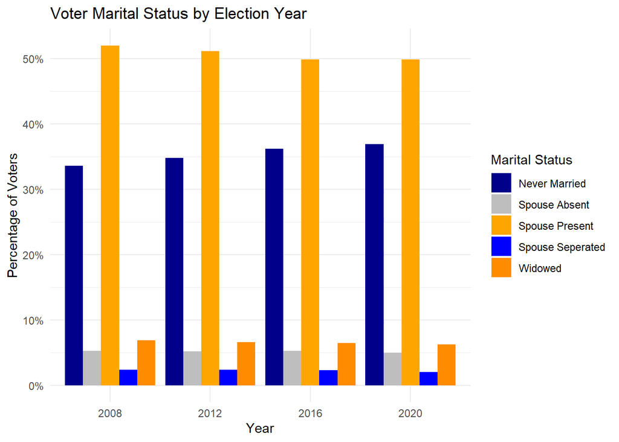

```r
mar_fill_colors <- c("Never Married"="darkblue","Spouse Present"="orange","Spouse Absent"= "gray", "Spouse Seperated"="blue","Widowed"="darkorange")
ggplot(marital_status_df_pivot, aes(x = year, y = percentage, fill = variable)) +
  geom_bar(stat = "identity", position = "dodge") +
  scale_y_continuous(labels = percent_format()) +
  scale_fill_manual(name = "Marital Status",values=mar_fill_colors) +
  labs(title = "Voter Marital Status by Election Year",
       x = "Year",
       y = "Percentage of Voters") +
  theme_minimal()
```

#### Gender by Election Year

```r
gender_df <- merged_df %>% select(
  year,
  total_males,
  total_females
) %>% group_by(year) %>%
  summarise(
    total_males = sum(total_males,na.rm=TRUE),
    total_females = sum(total_females,na.rm=TRUE)
  )
```

```r
gender_df_pivot <- gender_df %>% pivot_longer(
  cols = c(total_males, total_females),
  names_to = "variable",
  values_to = "value"
) %>% mutate(variable = recode(variable,
                               total_males = "Male",
                               total_females = "Female", ))
gender_df_pivot <- gender_df_pivot %>% group_by(year) %>% mutate(percentage = value / sum(value))
gender_df_pivot$year <- as.factor(gender_df_pivot$year)
head(gender_df_pivot,20)
```

```
## # A tibble: 8 × 4
## # Groups:   year [4]
##   year  variable     value percentage
##   <fct> <chr>        <dbl>      <dbl>
## 1 2008  Male     444154497      0.493
## 2 2008  Female   457281702      0.507
## 3 2012  Male     454548243      0.492
## 4 2012  Female   469817271      0.508
## 5 2016  Male     468676260      0.492
## 6 2016  Female   483733461      0.508
## 7 2020  Male     734855459      0.493
## 8 2020  Female   757100604      0.507
```

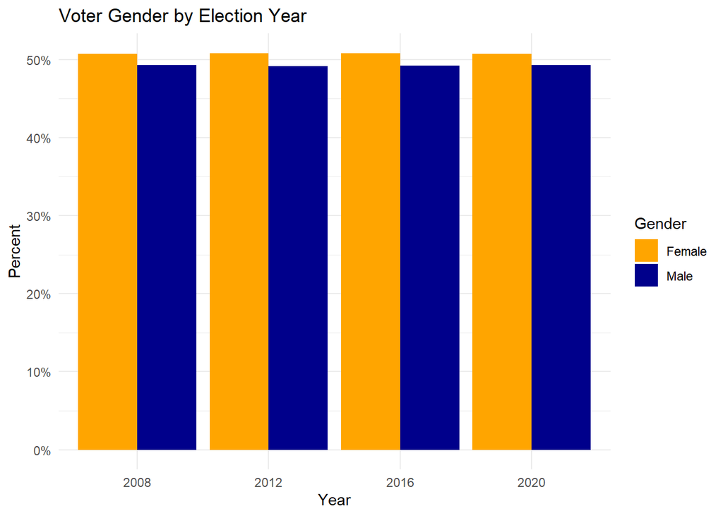

```r
gend_fill_colors <- c("Male"="darkblue","Female"="orange")
ggplot(gender_df_pivot, aes(x = year, y = percentage, fill = variable)) +
  geom_bar(stat = "identity", position = "dodge") +
  scale_fill_manual(name = "Gender",values=gend_fill_colors) +
  scale_y_continuous(labels = percent_format()) +
  labs(title = "Voter Gender by Election Year",
       x = "Year",
       y = "Percent") +
  theme_minimal()
```

### Total Vote Maps

Getting total votes by state and year from merged_df.

```r
state_votes <- merged_df %>% select(year,state,totalvotes) %>% group_by(year,state)
state_votes <- state_votes %>% mutate(state=tolower(state))
head(state_votes)
```

```
## # A tibble: 6 × 3
## # Groups:   year, state [1]
##    year state   totalvotes
##   <dbl> <chr>        <dbl>
## 1  2008 alabama      23641
## 2  2008 alabama      23641
## 3  2008 alabama      23641
## 4  2008 alabama      81413
## 5  2008 alabama      81413
## 6  2008 alabama      81413
```

Merging total vote and state geometry data for the maps.

```r
state_geomDf <- map_data("state")
merged_state_votes_geom <- merge(state_votes, state_geomDf,by.x = "state", by.y = "region")
head(merged_state_votes_geom)
```

```
##     state year totalvotes      long      lat group order subregion
## 1 alabama 2008      14956 -87.46201 30.38968     1     1      <NA>
## 2 alabama 2008      14956 -87.48493 30.37249     1     2      <NA>
## 3 alabama 2008      14956 -87.95475 30.24644     1    13      <NA>
## 4 alabama 2008      14956 -88.00632 30.24071     1    14      <NA>
## 5 alabama 2008      14956 -88.01778 30.25217     1    15      <NA>
## 6 alabama 2008      14956 -87.52503 30.37249     1     3      <NA>
```

Creating data sets for each map.

```r
merged_state_votes_geom_08 <- merged_state_votes_geom %>% filter(year==2008) %>% group_by(year,state,order,group,lat,long) %>% summarise(state_total_votes = sum(totalvotes)) %>% ungroup()
```

```
## You can override using the `.groups` argument.
```

```r
merged_state_votes_geom_12 <- merged_state_votes_geom %>% filter(year==2012) %>% group_by(year,state,order,group,lat,long) %>% summarise(state_total_votes = sum(totalvotes)) %>% ungroup()
```

```
## You can override using the `.groups` argument.
```

```r
merged_state_votes_geom_16 <- merged_state_votes_geom %>% filter(year==2016) %>% group_by(year,state,order,group,lat,long) %>% summarise(state_total_votes = sum(totalvotes)) %>% ungroup()
```

```
## You can override using the `.groups` argument.
```

```r
merged_state_votes_geom_20 <- merged_state_votes_geom %>% filter(year==2020) %>% group_by(year,state,order,group,lat,long) %>% summarise(state_total_votes = sum(totalvotes)) %>% ungroup()
```

```
## You can override using the `.groups` argument.
```

```r
head(merged_state_votes_geom_08)
```

```
## # A tibble: 6 × 7
##    year state   order group   lat  long state_total_votes
##   <dbl> <chr>   <int> <dbl> <dbl> <dbl>             <dbl>
## 1  2008 alabama     1     1  30.4 -87.5           6299457
## 2  2008 alabama     2     1  30.4 -87.5           6299457
## 3  2008 alabama     3     1  30.4 -87.5           6299457
## 4  2008 alabama     4     1  30.3 -87.5           6299457
## 5  2008 alabama     5     1  30.3 -87.6           6299457
## 6  2008 alabama     6     1  30.3 -87.6           6299457
```

2008 Total Vote Map

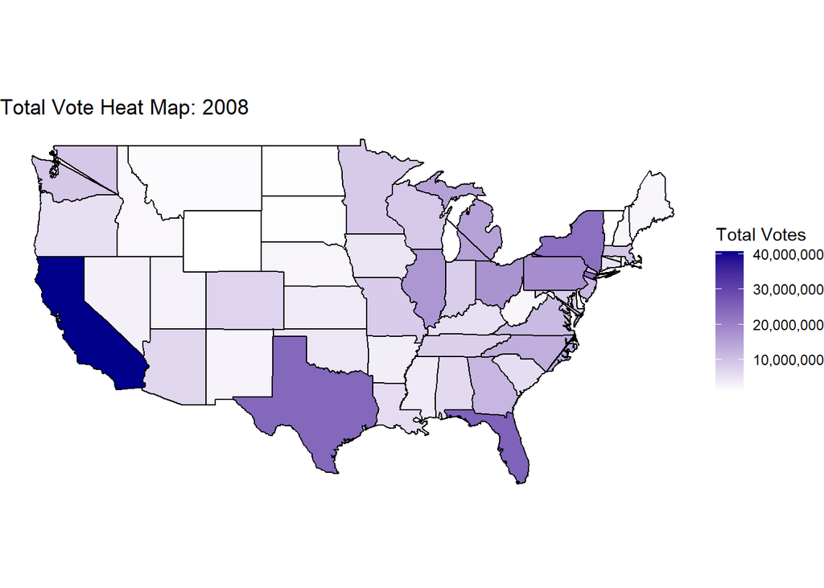

```r
ggplot(merged_state_votes_geom_08) +
  geom_polygon(color = "black", aes(
    x = long,
    y = lat,
    group = state,
    fill = state_total_votes
  )) +
  coord_map() +
  scale_fill_gradient(
    name = "Total Votes",
    low = "white",
    high = "darkblue",
    labels = scales::comma
  ) +
  labs(
    title = "Total Vote Heat Map: 2008"
  ) + theme_void()
```

2012 Total Vote Map

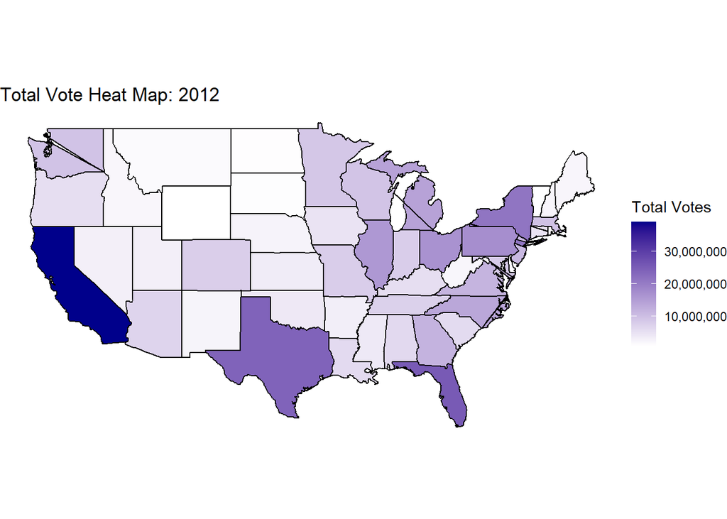

```r
ggplot(merged_state_votes_geom_12) +
  geom_polygon(color = "black", aes(
    x = long,
    y = lat,
    group = state,
    fill = state_total_votes
  )) +
  coord_map() +
  scale_fill_gradient(
    name = "Total Votes",
    low = "white",
    high = "darkblue",
    labels = scales::comma
  ) +
  labs(
    title = "Total Vote Heat Map: 2012"
  ) + theme_void()
```

2016 Total Vote Map

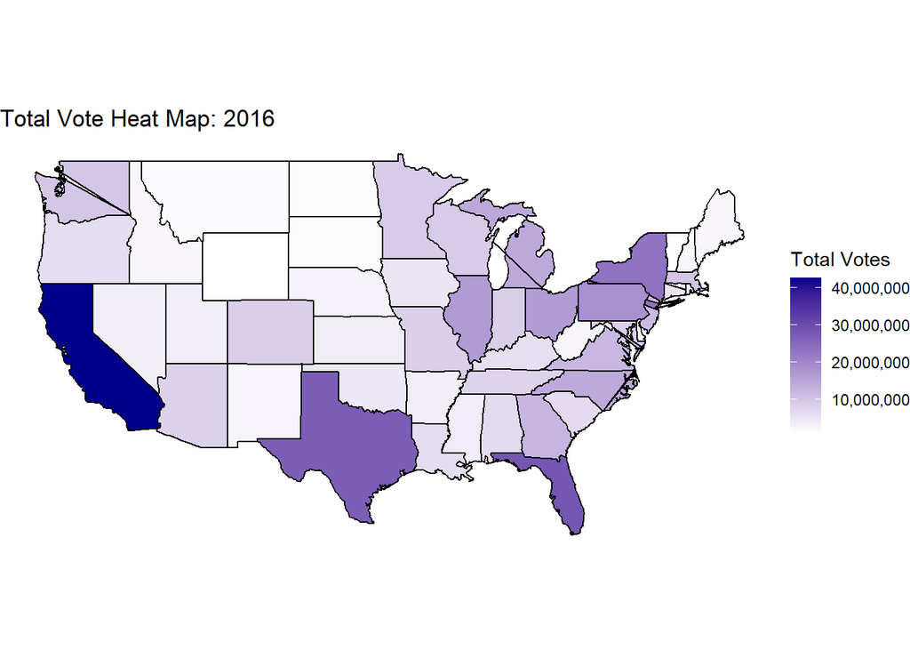

```r
ggplot(merged_state_votes_geom_16) +
  geom_polygon(color = "black", aes(
    x = long,
    y = lat,
    group = state,
    fill = state_total_votes
  )) +
  coord_map() +
  scale_fill_gradient(
    name = "Total Votes",
    low = "white",
    high = "darkblue",
    labels = scales::comma
  ) +
  labs(
    title = "Total Vote Heat Map: 2016"
  ) + theme_void()
```

2020 Total Vote Map

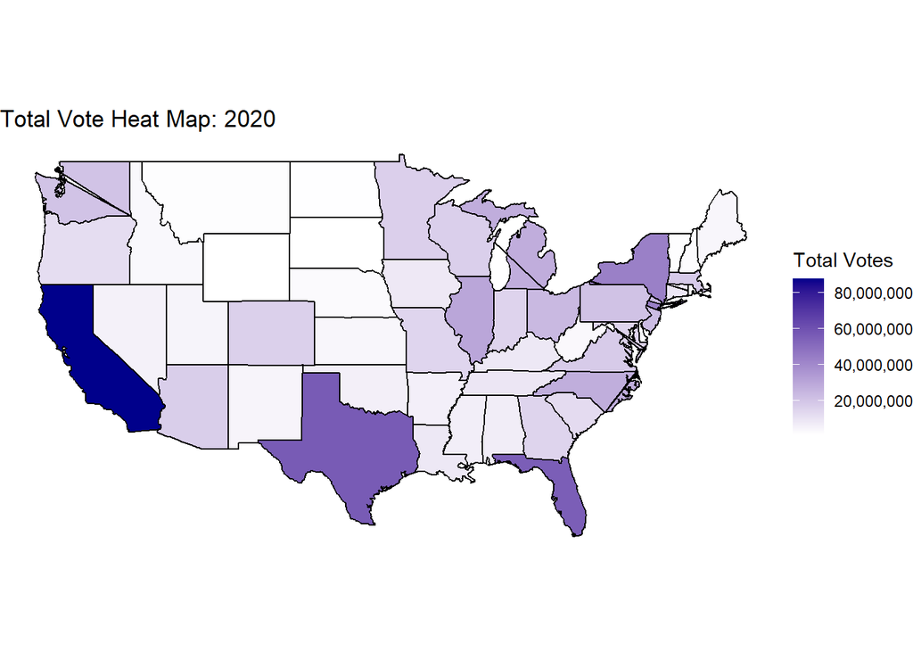

```r
ggplot(merged_state_votes_geom_20) +
  geom_polygon(color = "black", aes(
    x = long,
    y = lat,
    group = state,
    fill = state_total_votes
  )) +
  coord_map() +
  scale_fill_gradient(
    name = "Total Votes",
    low = "white",
    high = "darkblue",
    labels = scales::comma
  ) +
  labs(
    title = "Total Vote Heat Map: 2020"
  ) + theme_void()
```

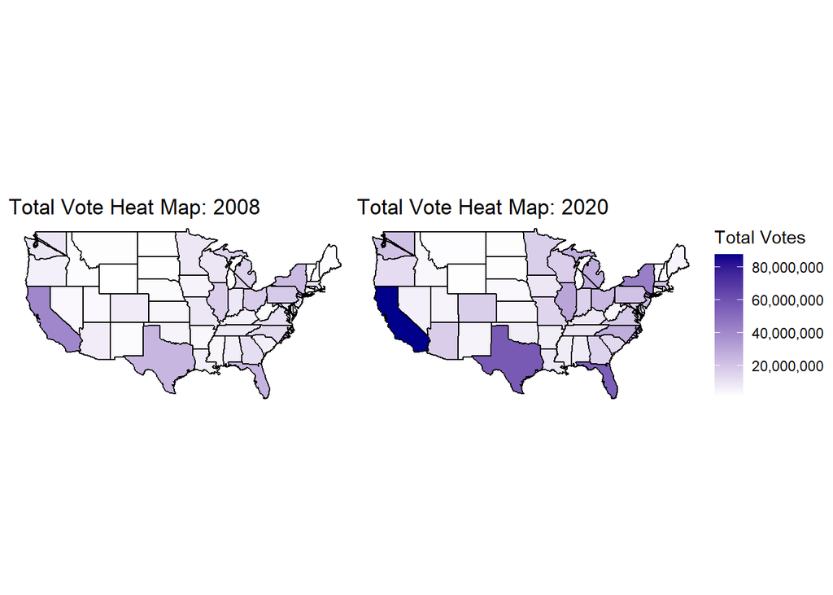

```r
library(patchwork)

# Set the overall data range
min_value <- min(c(merged_state_votes_geom_08$state_total_votes, merged_state_votes_geom_20$state_total_votes))
max_value <- max(c(merged_state_votes_geom_08$state_total_votes, merged_state_votes_geom_20$state_total_votes))

# Define a common color scale
color_scale <- scale_fill_gradient(
  name = "Total Votes",
  low = "white",
  high = "darkblue",  # Ensure both graphs share the same color scale
  limits = c(min_value, max_value),  # Set consistent min/max values
  labels = scales::comma
)

# First map (2008)
plot_08 <- ggplot(merged_state_votes_geom_08) +
  geom_polygon(color = "black", aes(
    x = long,
    y = lat,
    group = state,
    fill = state_total_votes
  )) +
  coord_map() +
  color_scale +
  labs(title = "Total Vote Heat Map: 2008") +
  theme_void() +
  theme(legend.position = "none")  # Remove the legend

# Second map (2020)
plot_20 <- ggplot(merged_state_votes_geom_20) +
  geom_polygon(color = "black", aes(
    x = long,
    y = lat,
    group = state,
    fill = state_total_votes
  )) +
  coord_map() +
  color_scale +
  labs(title = "Total Vote Heat Map: 2020") +
  theme_void()

# Combine the two graphs into a single layout (keeping only plot_20's legend)
(plot_08 + plot_20) + plot_layout(nrow = 1, ncol = 2)
```

## Modeling

This section details the steps taken to train, predict and evaluate our SVM and Random Forest models.

### Training and Test Data Sets

Creating our training and test data sets.

```r
set.seed(123)
split_ds <- sample.split(merged_df_winners_Pre2020$winner, .70)
train <- subset(merged_df_winners_Pre2020, split_ds == TRUE)
test <- subset(merged_df_winners_Pre2020, split_ds == FALSE)
```

We scale our data to help improve the final accuracy of model.

```r
train_ds_scaled <- train %>% mutate(across(where(is.numeric), scale))
test_ds_scaled <- test %>% mutate(across(where(is.numeric), scale))
```

### Support Vector Machine

We first used a support vector machine with configurations we covered in our coursework to make a prediction using our training and test data.

```r
trnCntrl <- trainControl(method="cv", number=3)
tune_grid = expand.grid(sigma= c(0.01, 0.05, 0.1),C=c(1,2,3))
set.seed(123)
svm_model <- train(winner~.,
                   data=train_ds_scaled,
                   method="svmRadial",
                   tuneGrid=tune_grid,
                   trControl = trnCntrl,
                   preProcess = c("center", "scale")
                   )
```

#### Predictions & Evaluation

Taking a look at the final model.

```r
svm_model$finalModel
```

```
## Support Vector Machine object of class "ksvm"
##
## SV type: C-svc  (classification)
##  parameter : cost C = 3
##
## Gaussian Radial Basis kernel function.
##  Hyperparameter : sigma =  0.1
##
## Number of Support Vectors : 2250
##
## Objective Function Value : -5341.851
## Training error : 0.113609
```

Generating predictions.

```r
set.seed(123)
svm_model_predictions <- predict(svm_model,
                                newdata = select(test_ds_scaled, -winner),
                                type = "raw")
```

Confusion Matrix.

```r
svm_conf_matrix <- confusionMatrix(as.factor(svm_model_predictions),as.factor(test_ds_scaled$winner))
svm_conf_matrix
```

```
## Confusion Matrix and Statistics
##
##             Reference
## Prediction   DEMOCRAT REPUBLICAN
##   DEMOCRAT        318         67
##   REPUBLICAN      299       2118
##
##                Accuracy : 0.8694
##                  95% CI : (0.8563, 0.8816)
##     No Information Rate : 0.7798
##     P-Value [Acc > NIR] : < 2.2e-16
##
##                   Kappa : 0.5603
##
##  Mcnemar's Test P-Value : < 2.2e-16
##
##             Sensitivity : 0.5154
##             Specificity : 0.9693
##          Pos Pred Value : 0.8260
##          Neg Pred Value : 0.8763
##              Prevalence : 0.2202
##          Detection Rate : 0.1135
##    Detection Prevalence : 0.1374
##       Balanced Accuracy : 0.7424
##
##        'Positive' Class : DEMOCRAT
##
```

Accuracy.

```r
svm_accuracy <- sum(diag(svm_conf_matrix$table)) / sum(svm_conf_matrix$table)
print(paste("Test Accuracy:", round(svm_accuracy, 3)))
```

```
## [1] "Test Accuracy: 0.869"
```

Visualizing the Confusion Matrix.

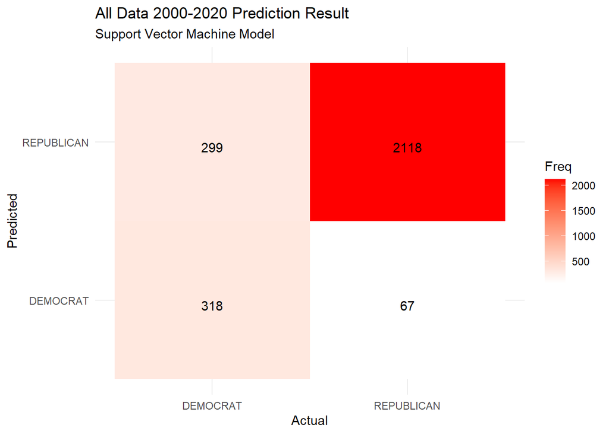

```r
svm_cm_df <- as.data.frame(svm_conf_matrix$table)
svm_cm_plot <- ggplot(data = svm_cm_df, aes(x = Reference, y = Prediction, fill = Freq)) +
  geom_tile() +
  geom_text(aes(label = Freq), vjust = 1) +
  scale_fill_gradient(low = "white", high = "red") +
  labs(title = "All Data 2000-2020 Prediction Result", x = "Actual", y = "Predicted"
       ,subtitle = "Support Vector Machine Model") +
  theme_minimal()
svm_cm_plot
```

### Base Random Forest Model

We decided to try using a random forest model predict the winner based on the same training and test data we used in the SVM Model.

```r
set.seed(123)
rf_base_model <- randomForest(as.factor(winner) ~ ., data = train_ds_scaled, ntree = 100, mtry = 3, importance = TRUE)
```

#### Predictions & Evalution

Generating predictions.

```r
rf_base_predictions <- predict(rf_base_model, test_ds_scaled)
```

Confusion Matrix.

```r
rf_base_conf_matrix <- confusionMatrix(as.factor(rf_base_predictions), as.factor(test_ds_scaled$winner))
print(rf_base_conf_matrix)
```

```
## Confusion Matrix and Statistics
##
##             Reference
## Prediction   DEMOCRAT REPUBLICAN
##   DEMOCRAT        351        148
##   REPUBLICAN      266       2037
##
##                Accuracy : 0.8522
##                  95% CI : (0.8386, 0.8652)
##     No Information Rate : 0.7798
##     P-Value [Acc > NIR] : < 2.2e-16
##
##                   Kappa : 0.5381
##
##  Mcnemar's Test P-Value : 8.912e-09
##
##             Sensitivity : 0.5689
##             Specificity : 0.9323
##          Pos Pred Value : 0.7034
##          Neg Pred Value : 0.8845
##              Prevalence : 0.2202
##          Detection Rate : 0.1253
##    Detection Prevalence : 0.1781
##       Balanced Accuracy : 0.7506
##
##        'Positive' Class : DEMOCRAT
##
```

Accuracy.

```r
rf_base_accuracy <- sum(diag(rf_base_conf_matrix$table)) / sum(rf_base_conf_matrix$table)
print(paste("Test Accuracy:", round(rf_base_accuracy, 3)))
```

```
## [1] "Test Accuracy: 0.852"
```

Visualizing the Confusion Matrix.

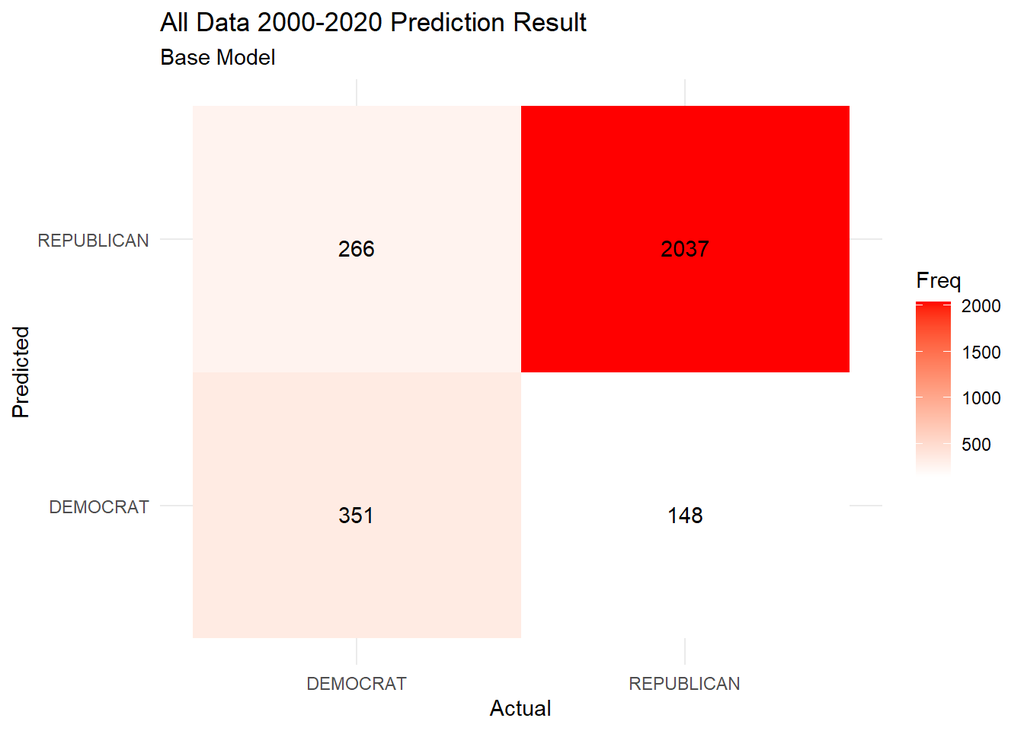

```r
cmt <- as.data.frame(rf_base_conf_matrix$table)

og_plot <- ggplot(data = cmt, aes(x = Reference, y = Prediction, fill = Freq)) +
  geom_tile() +
  geom_text(aes(label = Freq), vjust = 1) +
  scale_fill_gradient(low = "white", high = "red") +
  labs(title = "All Data 2000-2020 Prediction Result", x = "Actual", y = "Predicted"
       ,subtitle = "Base Model") +
  theme_minimal()
og_plot
```

#### Variable Importance

A complete list of variables ordered by importance.

```r
importance(rf_base_model)
```

```
##                                    DEMOCRAT REPUBLICAN MeanDecreaseAccuracy
## county_fips                      11.0695938  11.463863            14.876983
## candidatevotes                    2.1281836  11.349927            13.073772
## totalvotes                        4.1089198  11.033823            12.288799
## total_males                      -0.9357054   9.767879            10.329590
## total_females                     2.1913531  10.794766            11.817690
## median_age                        9.9491738  12.178891            14.526169
## median_household_income           7.1165729  16.159969            17.426940
## aggregate_household_income        0.7223303   8.938036             9.892609
## median_home_value                10.6027381  13.972789            16.608017
## median_mortgage_payment          10.3234596  11.507277            13.309123
## white                            -1.4257160  16.322078            17.887769
## black                            10.8819431  21.242968            21.764011
## american_indian_alaska_native     3.8635697  11.193857            12.569150
## asian_alone                       5.2140516   6.581563             7.926498
## native_hawaiian_pacific_islander  0.8330368   8.922439             9.240245
## other_race                        3.5087175   9.713919            11.379875
## hispanic_or_latino               -0.1375356  14.087070            13.960258
## citizen                          -2.6963506  11.270925            11.854360
## non_citizen                       6.1714048   7.949373             9.846365
## high_school_education            -0.8780010  10.116203            10.647176
## associates_degree                 1.8188317   7.968847             8.793652
## bachelor_degree                   0.6112969   9.378883             9.756244
## masters_degree                    2.6372664   9.231444            10.308464
## doctoral_degree                   4.1224784  12.628364            14.141092
## recieved_food_stamps              3.1558593  11.164496            12.721063
## did_not_recieved_food_stamps     -0.2774222   8.541509             8.976381
## employed                          0.9780697   8.497647             9.796841
## unemployed                        1.4866228   9.941970            11.125492
## not_in_labor_force                4.2553342  10.280810            11.410065
## never_married                     7.7439279  11.071716            13.647325
## spouse_present                   -3.9245209  12.936531            13.972776
## spouse_absent                     1.6728672  10.733606            11.914446
## spouse_seperated                  0.8479677  11.602516            12.591638
## widowed                           5.5665938   9.815304            12.028837
##                                  MeanDecreaseGini
## county_fips                              69.49940
## candidatevotes                           49.12469
## totalvotes                               77.19610
## total_males                              55.29327
```

[output cut: 15 more lines]

```
## high_school_education                    53.76100
## associates_degree                        50.93325
## bachelor_degree                          55.15220
## masters_degree                           63.11604
## doctoral_degree                          99.78240
## recieved_food_stamps                     57.51226
## did_not_recieved_food_stamps             47.10918
## employed                                 47.78129
## unemployed                               61.74101
## not_in_labor_force                       61.69804
## never_married                           102.53959
## spouse_present                           70.94933
## spouse_absent                            70.59071
## spouse_seperated                         55.65033
## widowed                                  58.05155
```

Visualized using varImpPlot

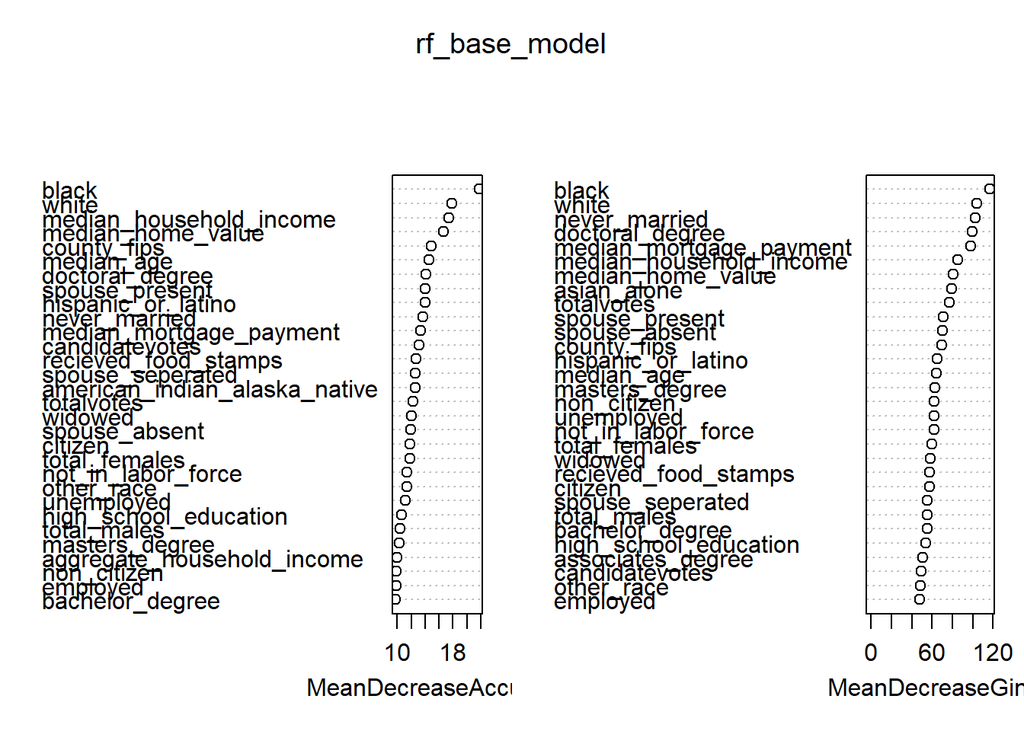

```r
varImpPlot(rf_base_model)
```

### Incorporating Cross-Validation

In this version, we take our base model and add 5-fold cross-validation in order to help the model learn generally and does not memorize patterns.

```r
set.seed(123)
train_control <- trainControl(method = "cv", number = 5)  # 5-Fold Cross Validation
rf_cv_model <- train(
  as.factor(winner) ~ .,
  data = train_ds_scaled,
  method = "rf",
  trControl = train_control,
  importance = TRUE
)
```

#### Predictions & Evaluation

Generating predictions with 5-fold cross-validation.

```r
rf_cv_predictions <- predict(rf_cv_model, test_ds_scaled)
```

Confusion Matrix.

```r
rf_cv_conf_matrix <- confusionMatrix(as.factor(rf_cv_predictions), as.factor(test_ds_scaled$winner))
print(rf_cv_conf_matrix)
```

```
## Confusion Matrix and Statistics
##
##             Reference
## Prediction   DEMOCRAT REPUBLICAN
##   DEMOCRAT        411        198
##   REPUBLICAN      206       1987
##
##                Accuracy : 0.8558
##                  95% CI : (0.8423, 0.8686)
##     No Information Rate : 0.7798
##     P-Value [Acc > NIR] : <2e-16
##
##                   Kappa : 0.5782
##
##  Mcnemar's Test P-Value : 0.7276
##
##             Sensitivity : 0.6661
##             Specificity : 0.9094
##          Pos Pred Value : 0.6749
##          Neg Pred Value : 0.9061
##              Prevalence : 0.2202
##          Detection Rate : 0.1467
##    Detection Prevalence : 0.2173
##       Balanced Accuracy : 0.7878
##
##        'Positive' Class : DEMOCRAT
##
```

Accuracy.

```r
rf_cv_accuracy <- sum(diag(rf_cv_conf_matrix$table)) / sum(rf_cv_conf_matrix$table)
print(paste("Test Accuracy:", round(rf_cv_accuracy, 3)))
```

```
## [1] "Test Accuracy: 0.856"
```

Visualizing the Confusion Matrix.

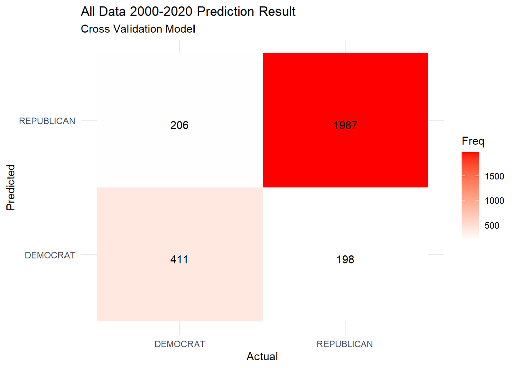

```r
mt <- as.data.frame(rf_cv_conf_matrix$table)

cv_plot <- ggplot(data = mt, aes(x = Reference, y = Prediction, fill = Freq)) +
  geom_tile() +
  geom_text(aes(label = Freq), vjust = 1) +
  scale_fill_gradient(low = "white", high = "red") +
  labs(title = "All Data 2000-2020 Prediction Result", x = "Actual", y = "Predicted"
       ,subtitle = "Cross Validation Model") +
  theme_minimal()
cv_plot
```

#### Variable Importance

```r
importance(rf_cv_model$finalModel)
```

```
##                                    DEMOCRAT REPUBLICAN MeanDecreaseAccuracy
## county_fips                      45.0361052   32.29383             45.74596
## candidatevotes                    7.9016236   22.16220             26.22159
## totalvotes                        4.3495096   18.96142             20.71430
## total_males                       0.1108414   14.14103             15.04572
## total_females                    -0.4867637   12.96757             13.63237
## median_age                       30.8229846   40.70414             51.73207
## median_household_income          21.3753623   48.23095             57.60179
## aggregate_household_income       -3.4352550   16.05977             16.43835
## median_home_value                32.1273730   44.10645             59.83104
## median_mortgage_payment          34.8471374   36.92469             48.07399
## white                             4.8195903   42.06538             47.93297
## black                            38.2201579   84.52942             98.30100
## american_indian_alaska_native     8.5061649   37.75011             38.05337
## asian_alone                      12.4846971   14.95441             19.44151
## native_hawaiian_pacific_islander  7.5157079   24.30304             26.31701
## other_race                       12.0350487   25.27514             29.62212
## hispanic_or_latino               -2.2516950   52.59139             55.09697
## citizen                          -4.8816098   14.53422             14.69854
## non_citizen                      11.5503994   20.54310             24.26114
## high_school_education             1.3643611   19.50134             21.10123
## associates_degree                 1.3071506   26.01241             27.64369
## bachelor_degree                   1.7321914   18.19033             19.26735
## masters_degree                    7.9756909   17.47186             20.51429
## doctoral_degree                  22.5361730   30.43455             37.00128
## recieved_food_stamps             14.0356174   41.03219             45.66215
## did_not_recieved_food_stamps      3.7411361   18.62157             20.20370
## employed                          0.5283083   14.71916             15.60947
## unemployed                        2.2133487   19.55306             20.64949
## not_in_labor_force                2.5578607   18.59037             20.56031
## never_married                    26.4616051   19.94031             29.06257
## spouse_present                   -6.2019018   25.39697             26.01379
## spouse_absent                    -0.3629268   21.77987             22.86839
## spouse_seperated                 -0.6802229   29.70091             30.94850
## widowed                           8.0338327   17.55847             20.85977
##                                  MeanDecreaseGini
## county_fips                             122.40097
## candidatevotes                           37.43832
## totalvotes                               34.61724
## total_males                              21.43170
```

[output cut: 15 more lines]

```
## high_school_education                    34.76616
## associates_degree                        37.75941
## bachelor_degree                          30.78713
## masters_degree                           44.04237
## doctoral_degree                         180.97833
## recieved_food_stamps                     63.70375
## did_not_recieved_food_stamps             38.76167
## employed                                 22.41227
## unemployed                               34.63300
## not_in_labor_force                       30.87490
## never_married                           204.68232
## spouse_present                           52.82004
## spouse_absent                            43.04193
## spouse_seperated                         50.72026
## widowed                                  30.25990
```

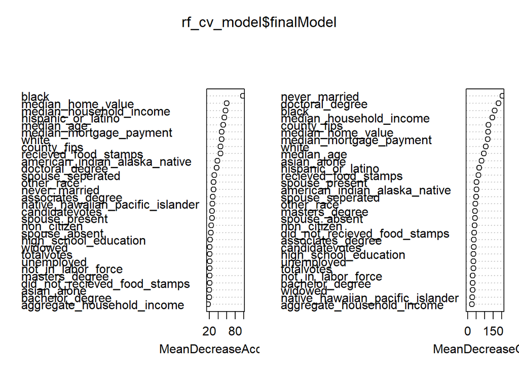

```r
varImpPlot(rf_cv_model$finalModel)
```

### Further Tuning our Model

We explored and tried a variety of techniques in this next section in order to improve the accuracy, sensitivity, specificity and precision of our model.

#### Applying Recursive Feature Elimination

We first compute the correlation matrix for the training data and then remove highly correlated features before applying recursive feature elimination.

```r
cor_matrix <- cor(train_ds_scaled %>% select(where(is.numeric)))
highly_correlated <- findCorrelation(cor_matrix, cutoff = 0.8)
train_filtered <- train_ds_scaled %>% select(-all_of(highly_correlated), winner)
test_filtered <- test_ds_scaled %>% select(-all_of(highly_correlated), winner)
```

Identifying the best variables to use in our model.

```r
rfe_ctrl <- rfeControl(functions = rfFuncs, method = "cv", number = 5)
rfe_result <- rfe(x = train_filtered[, -which(names(train_filtered) == "winner")],
                  y = as.factor(train_filtered$winner),
                  sizes = seq(5, min(ncol(train_filtered) - 1, 15), by = 5),
                  rfeControl = rfe_ctrl)

best_vars <- predictors(rfe_result)
```

Saving the best variables to use in our model.

```r
train_rfe <- train_filtered[, c(best_vars, "winner")]
test_rfe <- test_filtered[, c(best_vars, "winner")]
```

#### Tuning Hyperparameters

Looking for the optimal number of variables for each tree split.

```r
set.seed(123)
best_mtry <- tuneRF(train_rfe[, -which(names(train_rfe) == "winner")], as.factor(train_rfe$winner), stepFactor = 1.2, improve = 0.01)
```

```
## mtry = 3  OOB error = 11.5%
## Searching left ...
## Searching right ...
```

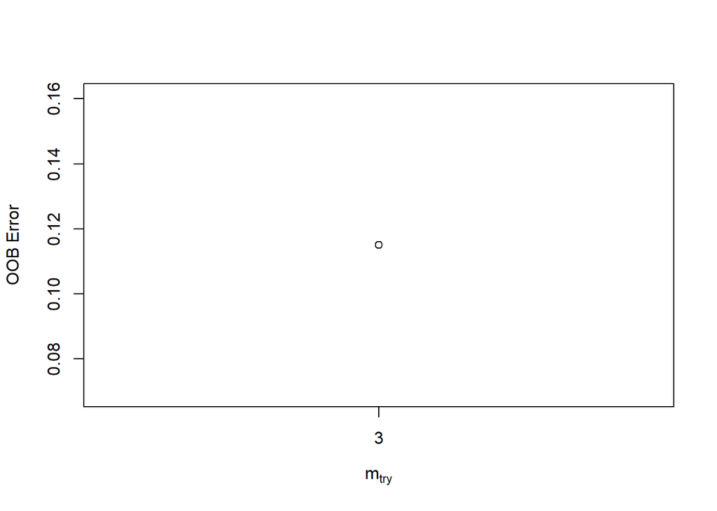

```r
best_mtry <- as.data.frame(best_mtry)
```

#### Optimizing Number of Trees

We test different numbers of trees for reach random forest model and record the results including the out of bag error which can help us define the optimal number of trees for the final model.

```r
tree_results <- data.frame()

set.seed(123)

for (ntree_val in seq(50, 500, by = 50)) {
  model <- randomForest(
    as.factor(winner) ~ .,
    data = train_rfe,
    ntree = ntree_val,
    mtry = 3,
    importance = TRUE
  )

  oob_error <- model$err.rate[nrow(model$err.rate), "OOB"] # Extract last row's OOB error

  tree_results <- rbind(tree_results,
                        data.frame(ntree = ntree_val, OOB_Error = oob_error))
}
```

Visualizing Bag Error vs Number of Trees

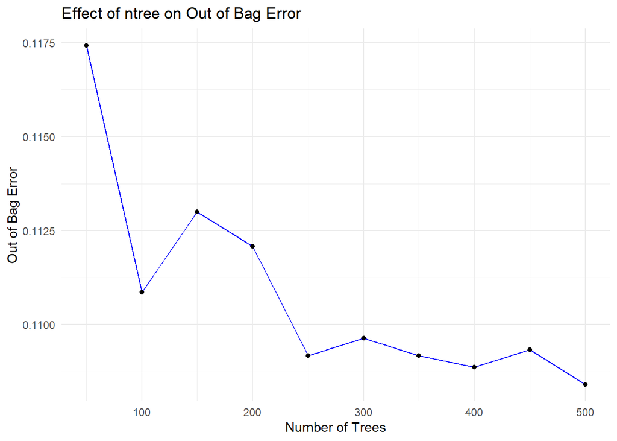

```r
ggplot(tree_results, aes(x = ntree, y = OOB_Error)) +
  geom_line(color = "blue") +
  geom_point() +
  labs(title = "Effect of ntree on Out of Bag Error", x = "Number of Trees", y = "Out of Bag Error") +
  theme_minimal()
```

#### Optimizing Node Size

Here we test different node sizes for each random forest model and record the results. The out of the bag error will produced here will help us choose the optimal node size for the final model.

```r
nodesize_results <- data.frame()

set.seed(123)

for (size in seq(1, 10, by = 1)) {
  model <- randomForest(
    as.factor(winner) ~ .,
    data = train_rfe,
    ntree = 100,
    mtry = 3,
    nodesize = size,
    importance = TRUE
  )

  oob_error <- model$err.rate[nrow(model$err.rate), "OOB"]

  nodesize_results <- rbind(nodesize_results,
                            data.frame(nodesize = size, OOB_Error = oob_error))
}
```

Visualizing the effect of node size on OOB error

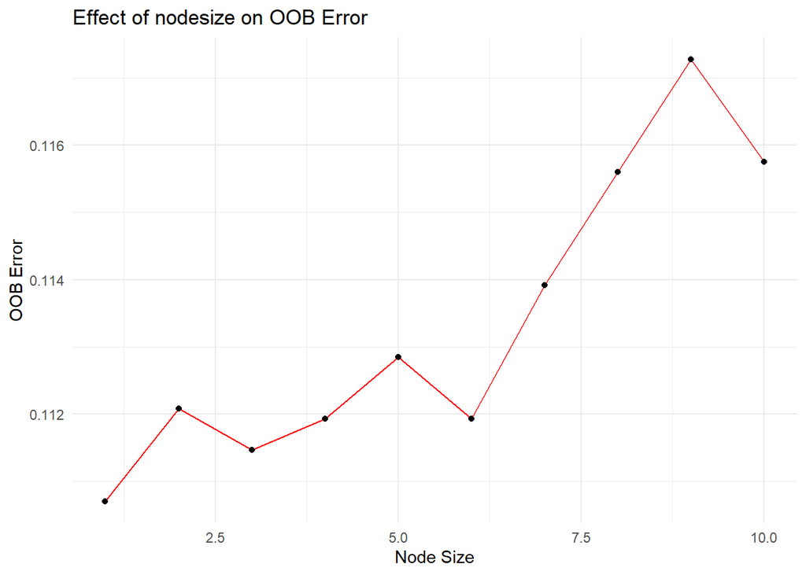

```r
ggplot(nodesize_results, aes(x = nodesize, y = OOB_Error)) +
  geom_line(color = "red") +
  geom_point() +
  labs(title = "Effect of nodesize on OOB Error", x = "Node Size", y = "OOB Error") +
  theme_minimal()
```

#### Setting Hyperparameters

We set the hyper parameters for number of trees and node size using the configurations with the lowest out of box errors from our models above.

```r
tuned_mtry <- best_mtry %>% filter(OOBError == min(OOBError))
tuned_trees <- tree_results %>% filter(OOB_Error == min(OOB_Error))
tuned_nodes <- nodesize_results %>% filter(OOB_Error == min(OOB_Error))
```

### Training our Optimized Model

Using our tuned hyperparameters, we train our final model.

```r
rf_final <- randomForest(
  as.factor(winner) ~ .,
  data = train_rfe,
  ntree = tuned_trees$ntree[1], ## get hypertuned parameter, if min has more than on value take the first
  mtry = tuned_mtry$mtry[1], ## get hypertuned parameter, if min has more than on value take the first
  nodesize = tuned_nodes$nodesize[1], ## get hypertuned parameter, if min has more than on value take the first
  importance = TRUE
)
```

#### Predictions & Evaluation

Below are our predictions and the evaluation of our fully tuned random forest model.

```r
predictions_final <- predict(rf_final, test_rfe)
conf_matrix_final <- confusionMatrix(as.factor(predictions_final), as.factor(test_rfe$winner))
print(conf_matrix_final)
```

```
## Confusion Matrix and Statistics
##
##             Reference
## Prediction   DEMOCRAT REPUBLICAN
##   DEMOCRAT        364        273
##   REPUBLICAN      253       1912
##
##                Accuracy : 0.8123
##                  95% CI : (0.7973, 0.8266)
##     No Information Rate : 0.7798
##     P-Value [Acc > NIR] : 1.338e-05
##
##                   Kappa : 0.4597
##
##  Mcnemar's Test P-Value : 0.4074
##
##             Sensitivity : 0.5900
##             Specificity : 0.8751
##          Pos Pred Value : 0.5714
##          Neg Pred Value : 0.8831
##              Prevalence : 0.2202
##          Detection Rate : 0.1299
##    Detection Prevalence : 0.2273
##       Balanced Accuracy : 0.7325
##
##        'Positive' Class : DEMOCRAT
##
```

Model Accuracy and Out of Bag Error

```r
# Print confusion matrix and accuracy
accuracy <- sum(diag(conf_matrix_final$table)) / sum(conf_matrix_final$table)
print(paste("Test Accuracy:", round(accuracy, 3)))
```

```
## [1] "Test Accuracy: 0.812"
```

```r
## Check Out-of-Bag (OOB) Error
print(head(rf_final$err.rate,10))
```

```
##             OOB  DEMOCRAT REPUBLICAN
##  [1,] 0.1865546 0.4133858 0.12500000
##  [2,] 0.1901572 0.3983353 0.13256579
##  [3,] 0.1912342 0.4088807 0.12859425
##  [4,] 0.1870767 0.3981788 0.12714454
##  [5,] 0.1840396 0.4040404 0.12201533
##  [6,] 0.1769695 0.3918819 0.11599665
##  [7,] 0.1737052 0.3949458 0.11104294
##  [8,] 0.1684740 0.3997145 0.10318420
##  [9,] 0.1620233 0.3961864 0.09582751
## [10,] 0.1614100 0.4000000 0.09399167
```

Visualizing our confusion matrix for our tuned model actual vs predicted results for Democrat and Republican winners.

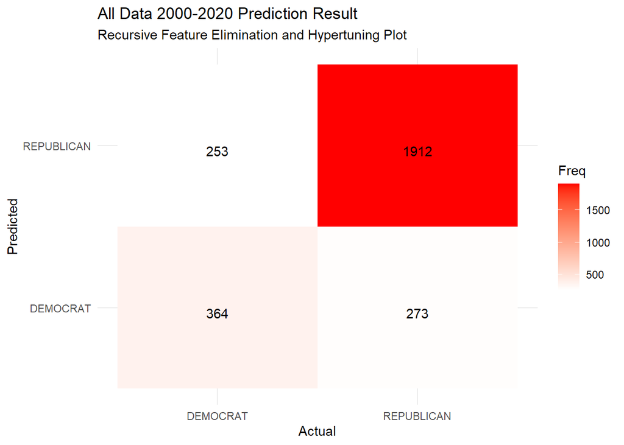

```r
rfe_table <- as.data.frame(conf_matrix_final$table)

rfe_plot <- ggplot(data = rfe_table, aes(x = Reference, y = Prediction, fill = Freq)) +
  geom_tile() +
  geom_text(aes(label = Freq), vjust = 1) +
  scale_fill_gradient(low = "white", high = "red") +
  labs(title = "All Data 2000-2020 Prediction Result", x = "Actual", y = "Predicted"
       ,subtitle = "Recursive Feature Elimination and Hypertuning Plot") +
  theme_minimal()
rfe_plot
```

#### Variable Importance

```r
importance(rf_final)
```

```
##                                   DEMOCRAT REPUBLICAN MeanDecreaseAccuracy
## black                            32.526372  102.71513            114.92235
## county_fips                      54.848824   44.31615             60.55216
## doctoral_degree                  20.209627   69.14414             76.62931
## median_age                       40.609156   50.37552             66.35880
## recieved_food_stamps             19.287236   53.01233             60.54598
## widowed                          15.104942   38.10913             45.66051
## white                            -3.625014   66.42698             73.03422
## asian_alone                      16.798621   34.52822             41.31923
## native_hawaiian_pacific_islander 12.067903   35.57899             39.19598
## total_females                     4.263764   42.04675             45.05960
##                                  MeanDecreaseGini
## black                                   302.17362
## county_fips                             240.49744
## doctoral_degree                         293.78390
## median_age                              187.45435
## recieved_food_stamps                    185.58837
## widowed                                 200.72781
## white                                   269.64749
## asian_alone                             240.74745
## native_hawaiian_pacific_islander         92.52378
## total_females                           234.73647
```

Visualize variable importance

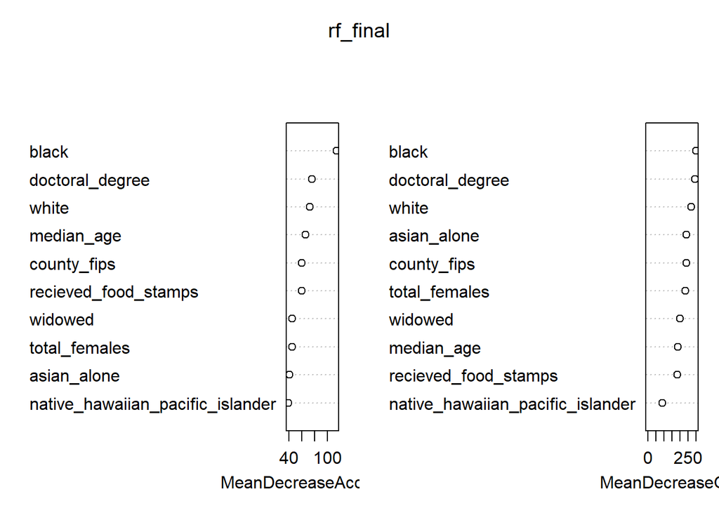

```r
varImpPlot(rf_final)
```

### Summarizing Results

[figure not shown]

```r
cm_plots <- (og_plot | cv_plot | rfe_plot)
cm_plots
```

## Balancing our Data with SMOTE

### Without Optimized Hyperparameters

Training a new model using balanced data with basic hyperparameters.

```r
set.seed(123)
train_balanced <- SMOTE(train_ds_scaled[, -which(names(train_ds_scaled) == "winner")],
                        train_ds_scaled$winner,
                        K = 5,
                        dup_size = 2)$data

colnames(train_balanced)[ncol(train_balanced)] <- "winner"

train_balanced$winner <- as.factor(train_balanced$winner)

rf_model_balanced <- randomForest(winner ~ ., data = train_balanced, ntree = 100, mtry = 3, importance = TRUE)
```

Predictions and Evaluation

```r
predictions_balanced <- predict(rf_model_balanced, test_ds_scaled)
conf_matrix_balanced <- confusionMatrix(as.factor(predictions_balanced), as.factor(test_ds_scaled$winner))
print(conf_matrix_balanced)
```

```
## Confusion Matrix and Statistics
##
##             Reference
## Prediction   DEMOCRAT REPUBLICAN
##   DEMOCRAT        335        132
##   REPUBLICAN      282       2053
##
##                Accuracy : 0.8522
##                  95% CI : (0.8386, 0.8652)
##     No Information Rate : 0.7798
##     P-Value [Acc > NIR] : < 2.2e-16
##
##                   Kappa : 0.5287
##
##  Mcnemar's Test P-Value : 2.426e-13
##
##             Sensitivity : 0.5429
##             Specificity : 0.9396
##          Pos Pred Value : 0.7173
##          Neg Pred Value : 0.8792
##              Prevalence : 0.2202
##          Detection Rate : 0.1196
##    Detection Prevalence : 0.1667
##       Balanced Accuracy : 0.7413
##
##        'Positive' Class : DEMOCRAT
##
```

### With Optimized Hyperparameters

Training with our optimized hyperparameters.

```r
set.seed(123)
train_balanced <- SMOTE(train_rfe[, -which(names(train_rfe) == "winner")],
                        train_rfe$winner,
                        K = 5,
                        dup_size = 2)$data

colnames(train_balanced)[ncol(train_balanced)] <- "winner"

train_balanced$winner <- as.factor(train_balanced$winner)

rf_model_balanced_rfe <- randomForest(winner ~ ., data = train_balanced
                                  , ntree = tuned_trees$ntree[1]
                                  , mtry = tuned_mtry$mtry[1]
                                  ,nodesize = tuned_nodes$nodesize[1]
                                  , importance = TRUE)
```

Predictions and Evaluation

```r
predictions_balanced_rfe <- predict(rf_model_balanced_rfe, test_ds_scaled)
conf_matrix_balanced_rfe <- confusionMatrix(as.factor(predictions_balanced_rfe), as.factor(test_ds_scaled$winner))
print(conf_matrix_balanced_rfe)
```

```
## Confusion Matrix and Statistics
##
##             Reference
## Prediction   DEMOCRAT REPUBLICAN
##   DEMOCRAT        367        224
##   REPUBLICAN      250       1961
##
##                Accuracy : 0.8308
##                  95% CI : (0.8164, 0.8445)
##     No Information Rate : 0.7798
##     P-Value [Acc > NIR] : 1.079e-11
##
##                   Kappa : 0.4999
##
##  Mcnemar's Test P-Value : 0.2508
##
##             Sensitivity : 0.5948
##             Specificity : 0.8975
##          Pos Pred Value : 0.6210
##          Neg Pred Value : 0.8869
##              Prevalence : 0.2202
##          Detection Rate : 0.1310
##    Detection Prevalence : 0.2109
##       Balanced Accuracy : 0.7461
##
##        'Positive' Class : DEMOCRAT
##
```